# E-shop Clothing: E-commerce Data Model Project

Tram Nguyen

11/27/2021

[interactive chart not shown]

### **👉 [Link to view and download the Report](https://drive.google.com/file/d/1kG77946CjgDpGWcFuti9tnQK3_Mdqkdc/preview)**

```r
library(tidyverse)
library(readr)
library(kableExtra)
library(xtable)
library(tseries)
library(knitr)
library(dplyr)
library(stargazer)
library(effects)
library(tidyverse)
library(readxl)
library(lmtest) #for coeftest() and bptest().
library(broom) #for glance() and tidy()
library(car) #for hccm()
library(forecast)
library(MASS)
eshop<-read.csv("eshopcontinent.csv")

head(eshop)
```

```
##   ï..year month day order country continent sessionID page1maincategory
## 1    2008     4   1     1      29    Europe         1                 1
## 2    2008     4   1     2      29    Europe         1                 1
## 3    2008     4   1     3      29    Europe         1                 2
## 4    2008     4   1     4      29    Europe         1                 2
## 5    2008     4   1     5      29    Europe         1                 2
## 6    2008     4   1     6      29    Europe         1                 3
##   page2clothingmodel colour location modelphotography price price2 page weekday
## 1                A13      1        5                1    28      0    1 Tuesday
## 2                A16      1        6                1    33      0    1 Tuesday
## 3                 B4     10        2                1    52      1    1 Tuesday
## 4                B17      6        6                2    38      0    1 Tuesday
## 5                 B8      4        3                2    52      1    1 Tuesday
## 6                C56      6        1                2    57      1    4 Tuesday
##   formal
## 1      1
## 2      1
## 3      0
## 4      1
## 5      0
## 6      1
```

```r
str(eshop)
```

```
## 'data.frame':    165474 obs. of  17 variables:
##  $ ï..year           : int  2008 2008 2008 2008 2008 2008 2008 2008 2008 2008 ...
##  $ month             : int  4 4 4 4 4 4 4 4 4 4 ...
##  $ day               : int  1 1 1 1 1 1 1 1 1 1 ...
##  $ order             : int  1 2 3 4 5 6 7 8 9 1 ...
##  $ country           : int  29 29 29 29 29 29 29 29 29 29 ...
##  $ continent         : chr  "Europe" "Europe" "Europe" "Europe" ...
##  $ sessionID         : int  1 1 1 1 1 1 1 1 1 2 ...
##  $ page1maincategory : int  1 1 2 2 2 3 3 4 4 2 ...
##  $ page2clothingmodel: chr  "A13" "A16" "B4" "B17" ...
##  $ colour            : int  1 1 10 6 4 6 5 9 6 9 ...
##  $ location          : int  5 6 2 6 3 1 1 5 4 5 ...
##  $ modelphotography  : int  1 1 1 2 2 2 2 1 2 1 ...
##  $ price             : int  28 33 52 38 52 57 33 38 48 57 ...
##  $ price2            : int  0 0 1 0 1 1 0 1 1 1 ...
##  $ page              : int  1 1 1 1 1 4 4 4 5 2 ...
##  $ weekday           : chr  "Tuesday" "Tuesday" "Tuesday" "Tuesday" ...
##  $ formal            : int  1 1 0 1 0 1 0 0 1 0 ...
```

```r
##convert "price" into log
head(eshop$lprice<-log(eshop$price),3)
```

```
## [1] 3.332205 3.496508 3.951244
```

## Model 1 - Linear Regression: Which attributes are most influential in predicting the price of a specific product?

To answer fully this question, we decided to separate the main question into 3 subsets questions: - (1) Which product’s attributes will affect the price ? - (2) Which website’s attributes will affect the price ? - (3) Who and when will affect the price ?

After we are able to answer all these 3 subsets questions, we will combine all the attributes and features from the products, website & customers to see how they together affect the price. Also, with 4 models are built, it will be easier for us to compare them, and give better conclusion about which one will be more accuracy & will affect the price more, products, website, customers & time or all of them together.

**Partitioning data**

Partitioning data with the ratio: 60% for train data set and 40% for valid data set.

```r
set.seed(1)

#training set
train.index <- sample(row.names(eshop), 0.6*dim(eshop)[1])
train.df <- eshop[train.index, ]

#validation set
valid.index <- setdiff(row.names(eshop), train.index)
valid.df <- eshop[valid.index, ]

head(train.df,3)
```

```
##        ï..year month day order country continent sessionID page1maincategory
## 24388     2008     4  14     3      29    Europe      3534                 2
## 124413    2008     7   8    43      46   Website     18259                 3
## 69586     2008     5  19     2      29    Europe     10037                 1
##        page2clothingmodel colour location modelphotography price price2 page
## 24388                 B13     12        5                2    62      1    1
## 124413                 C6      6        2                1    33      0    1
## 69586                 A15     14        5                2    33      0    1
##        weekday formal   lprice
## 24388   Monday      0 4.127134
## 124413 Tuesday      1 3.496508
## 69586   Monday      1 3.496508
```

```r
head(valid.df,3)
```

```
##   ï..year month day order country continent sessionID page1maincategory
## 2    2008     4   1     2      29    Europe         1                 1
## 3    2008     4   1     3      29    Europe         1                 2
## 4    2008     4   1     4      29    Europe         1                 2
##   page2clothingmodel colour location modelphotography price price2 page weekday
## 2                A16      1        6                1    33      0    1 Tuesday
## 3                 B4     10        2                1    52      1    1 Tuesday
## 4                B17      6        6                2    38      0    1 Tuesday
##   formal   lprice
## 2      1 3.496508
## 3      0 3.951244
## 4      1 3.637586
```

### 1/ Which product’s attributes will affect the price ?

```r
train.df1<-dplyr::select(train.df,lprice,page1maincategory,colour)
head(train.df1,3)
```

```
##          lprice page1maincategory colour
## 24388  4.127134                 2     12
## 124413 3.496508                 3      6
## 69586  3.496508                 1     14
```

#### a. Create dummy variables for train.df1

We create dummy variables for “page1maincategory”, which contains 4 types of products (trousers, blouses, skirt & other). With the “colour” variable, which contains 14 different colors.

```r
##create dummy for categorical variables

train.df1_dummy<-fastDummies::dummy_cols(train.df1,select_columns=c("page1maincategory","colour"),remove_selected_columns = T,remove_first_dummy = T)

head(train.df1_dummy)
```

```
##     lprice page1maincategory_2 page1maincategory_3 page1maincategory_4 colour_2
## 1 4.127134                   1                   0                   0        0
## 2 3.496508                   0                   1                   0        0
## 3 3.496508                   0                   0                   0        0
## 4 3.761200                   0                   0                   0        0
## 5 3.332205                   0                   1                   0        0
## 6 2.995732                   0                   1                   0        0
##   colour_3 colour_4 colour_5 colour_6 colour_7 colour_8 colour_9 colour_10
## 1        0        0        0        0        0        0        0         0
## 2        0        0        0        1        0        0        0         0
## 3        0        0        0        0        0        0        0         0
## 4        1        0        0        0        0        0        0         0
## 5        0        0        0        0        0        0        0         0
## 6        0        0        0        0        0        0        1         0
##   colour_11 colour_12 colour_13 colour_14
## 1         0         1         0         0
## 2         0         0         0         0
## 3         0         0         0         1
## 4         0         0         0         0
## 5         0         0         1         0
## 6         0         0         0         0
```

```r
mod1<-lm(lprice~.,data=train.df1_dummy)
summary(mod1)
```

```
##
## Call:
## lm(formula = lprice ~ ., data = train.df1_dummy)
##
## Residuals:
##      Min       1Q   Median       3Q      Max
## -0.71184 -0.19202 -0.00775  0.20487  0.75273
##
## Coefficients:
##                      Estimate Std. Error  t value Pr(>|t|)
## (Intercept)          3.645333   0.003547 1027.827   <2e-16 ***
## page1maincategory_2  0.123404   0.002639   46.763   <2e-16 ***
## page1maincategory_3 -0.115133   0.002709  -42.501   <2e-16 ***
## page1maincategory_4 -0.214718   0.002453  -87.532   <2e-16 ***
## colour_2             0.208194   0.004138   50.316   <2e-16 ***
## colour_3             0.239779   0.003966   60.453   <2e-16 ***
## colour_4             0.125711   0.004498   27.947   <2e-16 ***
## colour_5             0.124906   0.008666   14.413   <2e-16 ***
## colour_6             0.060873   0.004456   13.660   <2e-16 ***
## colour_7             0.007807   0.005443    1.434    0.152
## colour_8            -0.266014   0.006921  -38.437   <2e-16 ***
## colour_9             0.079004   0.004783   16.517   <2e-16 ***
## colour_10            0.182507   0.006727   27.131   <2e-16 ***
## colour_11            0.265228   0.005855   45.300   <2e-16 ***
## colour_12            0.216669   0.005161   41.979   <2e-16 ***
## colour_13            0.072015   0.005681   12.677   <2e-16 ***
## colour_14            0.124330   0.004584   27.124   <2e-16 ***
## ---
## Signif. codes:  0 '***' 0.001 '**' 0.01 '*' 0.05 '.' 0.1 ' ' 1
##
## Residual standard error: 0.2403 on 99267 degrees of freedom
## Multiple R-squared:  0.3089, Adjusted R-squared:  0.3088
## F-statistic:  2773 on 16 and 99267 DF,  p-value: < 2.2e-16
```

```r
mod1_exccolour7<-lm(lprice~.-colour_7,data=train.df1_dummy)
summary(mod1_exccolour7)
```

```
##
## Call:
## lm(formula = lprice ~ . - colour_7, data = train.df1_dummy)
##
## Residuals:
##     Min      1Q  Median      3Q     Max
## -0.7119 -0.1921 -0.0090  0.2047  0.7524
##
## Coefficients:
##                      Estimate Std. Error t value Pr(>|t|)
## (Intercept)          3.648428   0.002815 1296.26   <2e-16 ***
## page1maincategory_2  0.124297   0.002564   48.47   <2e-16 ***
## page1maincategory_3 -0.114018   0.002595  -43.94   <2e-16 ***
## page1maincategory_4 -0.213659   0.002339  -91.34   <2e-16 ***
## colour_2             0.204363   0.003160   64.66   <2e-16 ***
## colour_3             0.236472   0.003227   73.28   <2e-16 ***
## colour_4             0.121774   0.003563   34.17   <2e-16 ***
## colour_5             0.120709   0.008157   14.80   <2e-16 ***
## colour_6             0.056961   0.003524   16.16   <2e-16 ***
## colour_8            -0.269246   0.006543  -41.15   <2e-16 ***
## colour_9             0.074883   0.003824   19.58   <2e-16 ***
## colour_10            0.178518   0.006125   29.14   <2e-16 ***
## colour_11            0.261104   0.005101   51.19   <2e-16 ***
## colour_12            0.212647   0.004333   49.08   <2e-16 ***
## colour_13            0.067892   0.004900   13.86   <2e-16 ***
## colour_14            0.120352   0.003650   32.98   <2e-16 ***
## ---
## Signif. codes:  0 '***' 0.001 '**' 0.01 '*' 0.05 '.' 0.1 ' ' 1
##
## Residual standard error: 0.2403 on 99268 degrees of freedom
## Multiple R-squared:  0.3089, Adjusted R-squared:  0.3088
## F-statistic:  2957 on 15 and 99268 DF,  p-value: < 2.2e-16
```

```r
glance(mod1_exccolour7)
```

```
## # A tibble: 1 x 12
##   r.squared adj.r.squared sigma statistic p.value    df logLik    AIC    BIC
##       <dbl>         <dbl> <dbl>     <dbl>   <dbl> <dbl>  <dbl>  <dbl>  <dbl>
## 1     0.309         0.309 0.240     2957.       0    15   697. -1360. -1198.
## # ... with 3 more variables: deviance <dbl>, df.residual <int>, nobs <int>
```

```r
# Use stepAIC() to choose the better model
stepAIC(mod1)
```

```
## Start:  AIC=-283117.5
## lprice ~ page1maincategory_2 + page1maincategory_3 + page1maincategory_4 +
##     colour_2 + colour_3 + colour_4 + colour_5 + colour_6 + colour_7 +
##     colour_8 + colour_9 + colour_10 + colour_11 + colour_12 +
##     colour_13 + colour_14
##
##                       Df Sum of Sq    RSS     AIC
## <none>                             5731.9 -283118
## - colour_7             1      0.12 5732.0 -283117
## - colour_13            1      9.28 5741.2 -282959
## - colour_6             1     10.77 5742.7 -282933
## - colour_5             1     12.00 5743.9 -282912
## - colour_9             1     15.75 5747.7 -282847
## - colour_14            1     42.48 5774.4 -282386
## - colour_10            1     42.50 5774.4 -282386
## - colour_4             1     45.10 5777.0 -282341
## - colour_8             1     85.31 5817.2 -281653
## - colour_12            1    101.76 5833.7 -281372
## - page1maincategory_3  1    104.30 5836.2 -281329
## - colour_11            1    118.49 5850.4 -281088
## - page1maincategory_2  1    126.27 5858.2 -280956
## - colour_2             1    146.18 5878.1 -280619
## - colour_3             1    211.02 5942.9 -279530
## - page1maincategory_4  1    442.41 6174.3 -275738
```

```
##
## Call:
## lm(formula = lprice ~ page1maincategory_2 + page1maincategory_3 +
##     page1maincategory_4 + colour_2 + colour_3 + colour_4 + colour_5 +
##     colour_6 + colour_7 + colour_8 + colour_9 + colour_10 + colour_11 +
##     colour_12 + colour_13 + colour_14, data = train.df1_dummy)
##
## Coefficients:
##         (Intercept)  page1maincategory_2  page1maincategory_3
##            3.645333             0.123404            -0.115133
## page1maincategory_4             colour_2             colour_3
##           -0.214718             0.208194             0.239779
##            colour_4             colour_5             colour_6
##            0.125711             0.124906             0.060873
##            colour_7             colour_8             colour_9
##            0.007807            -0.266014             0.079004
##           colour_10            colour_11            colour_12
##            0.182507             0.265228             0.216669
##           colour_13            colour_14
##            0.072015             0.124330
```

The stepAIC suggests keep the colour_7, since its AIC is smaller than the model that exclude colour_7.

#### e. Check L.I.N.E assumptions

**Checking for Multicollinearity (VIF test)**

**Mod1-full model**

```r
vif1 <- tidy(vif(mod1))
kable(vif1,
caption="Variance product's attributes for the 'lprice' regression model",
col.names=c("regressor","VIF"))%>%
kable_styling(full_width = T)
```

Variance product’s attributes for the ‘lprice’ regression model

| regressor | VIF |
| --- | --- |
| page1maincategory_2 | 2.139301 |
| page1maincategory_3 | 2.252326 |
| page1maincategory_4 | 1.849898 |
| colour_2 | 4.346792 |
| colour_3 | 3.938665 |
| colour_4 | 3.129853 |
| colour_5 | 1.281095 |
| colour_6 | 3.243654 |
| colour_7 | 2.039164 |
| colour_8 | 1.328253 |
| colour_9 | 2.941855 |
| colour_10 | 1.595925 |
| colour_11 | 1.834105 |
| colour_12 | 2.346332 |
| colour_13 | 1.990776 |
| colour_14 | 3.128435 |

**Mod1_exccolour7 - Model that exclude colour_7**

```r
vif1.2 <- tidy(vif(mod1_exccolour7))
kable(vif1.2,
caption="Variance product's attributes for the 'lprice' regression model",
col.names=c("regressor","VIF"))%>%
kable_styling(full_width = T)
```

Variance product’s attributes for the ‘lprice’ regression model

| regressor | VIF |
| --- | --- |
| page1maincategory_2 | 2.020105 |
| page1maincategory_3 | 2.066798 |
| page1maincategory_4 | 1.682158 |
| colour_2 | 2.535810 |
| colour_3 | 2.607122 |
| colour_4 | 1.964207 |
| colour_5 | 1.135007 |
| colour_6 | 2.028225 |
| colour_8 | 1.187358 |
| colour_9 | 1.880272 |
| colour_10 | 1.323189 |
| colour_11 | 1.391869 |
| colour_12 | 1.653511 |
| colour_13 | 1.481015 |
| colour_14 | 1.983313 |

The rule of thumb is that a regressor produces collinearity if its VIF is greater than 10 . All our regressors have VIF coefficient less than 10, so there is no multicollinearity between each independent variables!

**Heteroscedasticity (breusch pagan test - bptest)**

```r
bptest(mod1)
```

```
##
##  studentized Breusch-Pagan test
##
## data:  mod1
## BP = 17338, df = 16, p-value < 2.2e-16
```

```r
bptest(mod1_exccolour7)
```

```
##
##  studentized Breusch-Pagan test
##
## data:  mod1_exccolour7
## BP = 17101, df = 15, p-value < 2.2e-16
```

**Linearity and Independence of Errors**

*Mod1 - Full model*

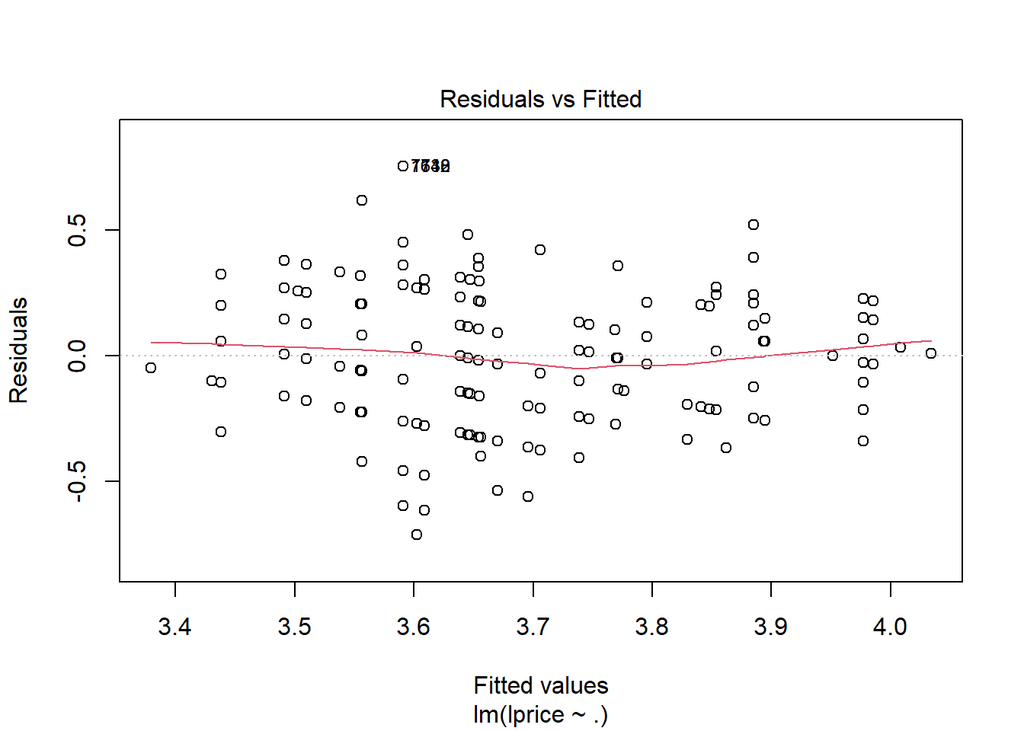

```r
#Linearity and Independence of Errors

plot(mod1, which = 1)
```

*Mod1_exccolour_7 - Model that exclude colour_7*

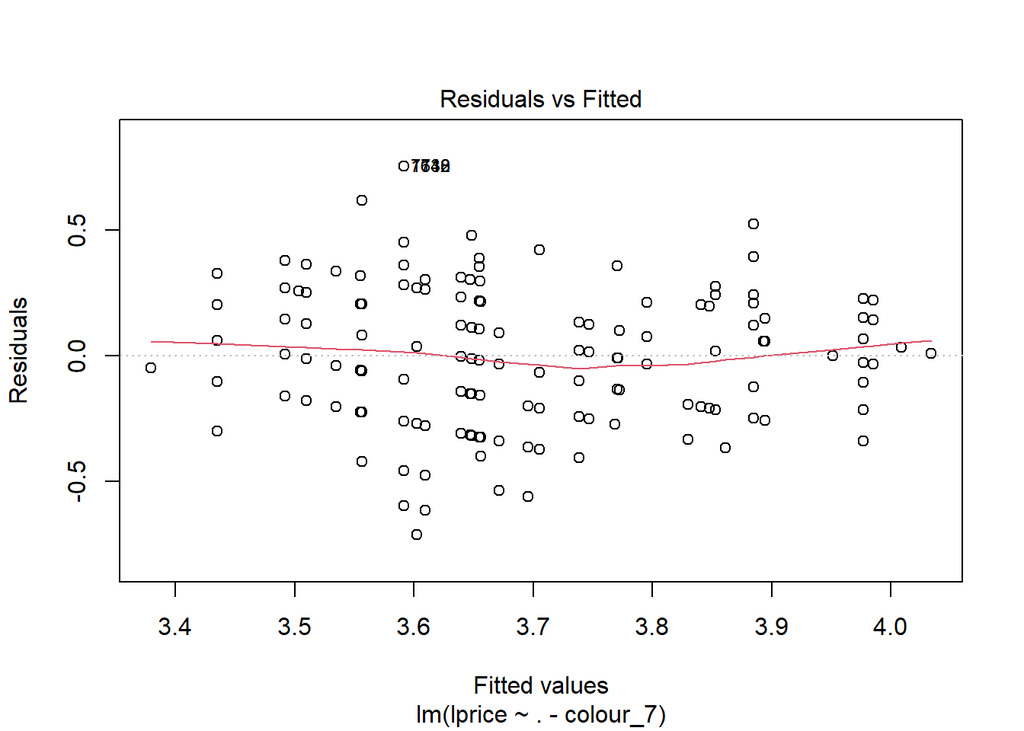

```r
#Linearity and Independence of Errors

plot(mod1_exccolour7, which = 1)
```

In the residuals versus fitted values plot, the points seem not totally randomly scattered, but it still appears not as a bad result.

**Normality of residuals**

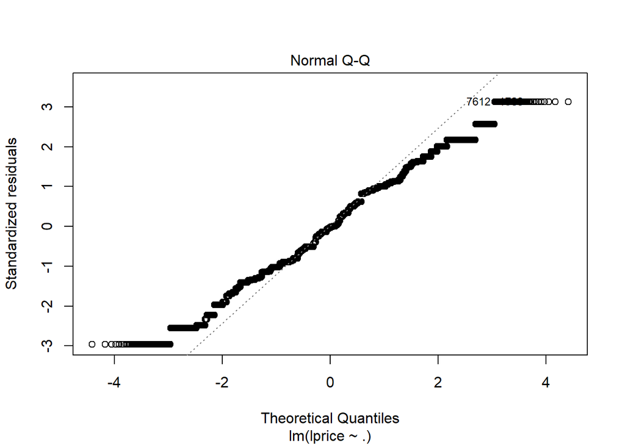

```r
plot(mod1, which = 2)
```

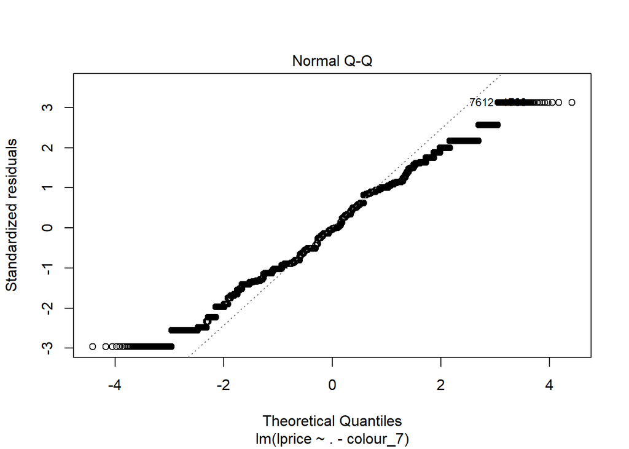

```r
plot(mod1_exccolour7,which=2)
```

Most of the data points fall close to the line, but there does appear to be a flat curve and There is some data point that stand out.

#### f. Evaluate model on valid data set

```r
valid.df1<-dplyr::select(valid.df,lprice,page1maincategory,colour)
valid.df1_dummy<-fastDummies::dummy_cols(valid.df1,select_columns = c("page1maincategory","colour"),remove_first_dummy = T,remove_selected_columns = T)
head(valid.df1_dummy)
```

```
##     lprice page1maincategory_2 page1maincategory_3 page1maincategory_4 colour_2
## 1 3.496508                   0                   0                   0        0
## 2 3.951244                   1                   0                   0        0
## 3 3.637586                   1                   0                   0        0
## 4 4.043051                   0                   1                   0        0
## 5 3.871201                   0                   0                   1        0
## 6 4.043051                   1                   0                   0        1
##   colour_3 colour_4 colour_5 colour_6 colour_7 colour_8 colour_9 colour_10
## 1        0        0        0        0        0        0        0         0
## 2        0        0        0        0        0        0        0         1
## 3        0        0        0        1        0        0        0         0
## 4        0        0        0        1        0        0        0         0
## 5        0        0        0        1        0        0        0         0
## 6        0        0        0        0        0        0        0         0
##   colour_11 colour_12 colour_13 colour_14
## 1         0         0         0         0
## 2         0         0         0         0
## 3         0         0         0         0
## 4         0         0         0         0
## 5         0         0         0         0
## 6         0         0         0         0
```

**Mod1 - Full Model**

```r
pred_training1 <- predict(mod1, data=train.df1_dummy, na.action=na.pass)
pred_valid1 <- predict(mod1, data=valid.df1_dummy, na.action=na.pass)
```

```r
## evaluate performance training
accuracy(pred_training1, train.df1_dummy$lprice)
```

```
##                     ME      RMSE       MAE        MPE     MAPE
## Test set -2.095688e-12 0.2402759 0.1990179 -0.4244415 5.385045
```

```r
## evaluate performance Validation
accuracy(pred_valid1, valid.df1_dummy$lprice)
```

```
##                    ME      RMSE       MAE        MPE    MAPE
## Test set 0.0006627667 0.3308101 0.2672707 -0.5959748 7.23913
```

**Mod1exccolour7 - Model exclude color 7**

```r
pred_training1.2 <- predict(mod1_exccolour7, data=train.df1_dummy, na.action=na.pass)
pred_valid1.2 <- predict(mod1_exccolour7, data=valid.df1_dummy, na.action=na.pass)
```

```r
## evaluate performance training
accuracy(pred_training1.2, train.df1_dummy$lprice)
```

```
##                     ME      RMSE       MAE        MPE     MAPE
## Test set -2.097085e-12 0.2402784 0.1990206 -0.4244556 5.385302
```

```r
## evaluate performance Validation
accuracy(pred_valid1.2, valid.df1_dummy$lprice)
```

```
##                   ME      RMSE       MAE        MPE    MAPE
## Test set 0.000662081 0.3308131 0.2672854 -0.5960042 7.23959
```

The mod1 - Full model seems to have less error rate than the model exclude colour_7.

### 2/ Which website’s attributes will affect the price ?

```r
train.df2<-dplyr::select(train.df,lprice,location,modelphotography,page)
head(train.df2,3)
```

```
##          lprice location modelphotography page
## 24388  4.127134        5                2    1
## 124413 3.496508        2                1    1
## 69586  3.496508        5                2    1
```

#### a. Create dummy variables for train.df1

```r
##create dummy for categorical variables
train.df2_dummy<-fastDummies::dummy_cols(train.df2,select_columns=c("location","modelphotography","page"),remove_selected_columns = T,remove_first_dummy = T)

head(train.df2_dummy)
```

```
##     lprice location_2 location_3 location_4 location_5 location_6
## 1 4.127134          0          0          0          1          0
## 2 3.496508          1          0          0          0          0
## 3 3.496508          0          0          0          1          0
## 4 3.761200          0          1          0          0          0
## 5 3.332205          1          0          0          0          0
## 6 2.995732          0          0          0          1          0
##   modelphotography_2 page_2 page_3 page_4 page_5
## 1                  1      0      0      0      0
## 2                  0      0      0      0      0
## 3                  1      0      0      0      0
## 4                  0      0      0      0      0
## 5                  0      0      1      0      0
## 6                  1      0      1      0      0
```

```r
mod2<-lm(lprice~.,data=train.df2_dummy)
summary(mod2)
```

```
##
## Call:
## lm(formula = lprice ~ ., data = train.df2_dummy)
##
## Residuals:
##      Min       1Q   Median       3Q      Max
## -0.70682 -0.17166 -0.01614  0.18794  0.72311
##
## Coefficients:
##                     Estimate Std. Error  t value Pr(>|t|)
## (Intercept)         3.806466   0.002067 1841.326   <2e-16 ***
## location_2         -0.029124   0.002702  -10.780   <2e-16 ***
## location_3          0.040352   0.003042   13.266   <2e-16 ***
## location_4          0.002784   0.002862    0.973    0.331
## location_5         -0.090061   0.002896  -31.102   <2e-16 ***
## location_6         -0.055918   0.003090  -18.098   <2e-16 ***
## modelphotography_2 -0.118089   0.002102  -56.183   <2e-16 ***
## page_2              0.035845   0.002081   17.229   <2e-16 ***
## page_3             -0.185772   0.002789  -66.611   <2e-16 ***
## page_4             -0.041690   0.004114  -10.134   <2e-16 ***
## page_5             -0.007898   0.006795   -1.162    0.245
## ---
## Signif. codes:  0 '***' 0.001 '**' 0.01 '*' 0.05 '.' 0.1 ' ' 1
##
## Residual standard error: 0.2714 on 99273 degrees of freedom
## Multiple R-squared:  0.1185, Adjusted R-squared:  0.1185
## F-statistic:  1335 on 10 and 99273 DF,  p-value: < 2.2e-16
```

```r
glance(mod2)
```

```
## # A tibble: 1 x 12
##   r.squared adj.r.squared sigma statistic p.value    df  logLik    AIC    BIC
##       <dbl>         <dbl> <dbl>     <dbl>   <dbl> <dbl>   <dbl>  <dbl>  <dbl>
## 1     0.119         0.118 0.271     1335.       0    10 -11377. 22779. 22893.
## # ... with 3 more variables: deviance <dbl>, df.residual <int>, nobs <int>
```

With the results above, we can conclude:

- Hypothesis test for whether all independent variables’ coefficient in the model equal to 0 or not - Ho: B1 + B2 + …+ Bk = 0. We see the F-statistic has p-value < 2.2e - 16, we can reject Ho, which means at least one independent variable has some effect on price (Or all independent variables’ coefficient together do not equal to 0).
- Hypothesis test for whether each independent variable’s coefficient in the model equals to 0 or not - Ho: Bk = 0. We see in the “Pr>(|t|)” column, most of values are <2e-16, we can reject Ho of those values, which means they have significant effect on price - their coefficients do not equal to 0. Except location_4 & page_5, their values is > 0.05 (location_4 0.331, page_5 0.245), we cannot reject Ho, location_4 & page_5 may not have any effect on price. We might consider to remove these variables.

```r
# Use stepAIC() to choose the better model
stepAIC(mod2)
```

```
## Start:  AIC=-258978.9
## lprice ~ location_2 + location_3 + location_4 + location_5 +
##     location_6 + modelphotography_2 + page_2 + page_3 + page_4 +
##     page_5
##
##                      Df Sum of Sq    RSS     AIC
## - location_4          1      0.07 7310.5 -258980
## - page_5              1      0.10 7310.5 -258980
## <none>                            7310.4 -258979
## - page_4              1      7.56 7318.0 -258878
## - location_2          1      8.56 7319.0 -258865
## - location_3          1     12.96 7323.4 -258805
## - page_2              1     21.86 7332.3 -258684
## - location_6          1     24.12 7334.5 -258654
## - location_5          1     71.23 7381.6 -258018
## - modelphotography_2  1    232.44 7542.8 -255873
## - page_3              1    326.74 7637.1 -254640
##
## Step:  AIC=-258980
## lprice ~ location_2 + location_3 + location_5 + location_6 +
##     modelphotography_2 + page_2 + page_3 + page_4 + page_5
##
##                      Df Sum of Sq    RSS     AIC
## - page_5              1      0.10 7310.6 -258981
## <none>                            7310.5 -258980
## - page_4              1      7.87 7318.3 -258875
## - location_2          1     11.92 7322.4 -258820
## - location_3          1     14.76 7325.2 -258782
## - page_2              1     21.83 7332.3 -258686
## - location_6          1     30.27 7340.7 -258572
## - location_5          1     91.89 7402.4 -257742
## - modelphotography_2  1    232.81 7543.3 -255870
## - page_3              1    327.23 7637.7 -254634
##
## Step:  AIC=-258980.6
## lprice ~ location_2 + location_3 + location_5 + location_6 +
##     modelphotography_2 + page_2 + page_3 + page_4
##
##                      Df Sum of Sq    RSS     AIC
## <none>                            7310.6 -258981
## - page_4              1      7.77 7318.3 -258877
## - location_2          1     11.96 7322.5 -258820
## - location_3          1     14.78 7325.3 -258782
## - page_2              1     22.26 7332.8 -258681
## - location_6          1     30.17 7340.7 -258574
## - location_5          1     92.01 7402.6 -257741
## - modelphotography_2  1    240.89 7551.4 -255764
## - page_3              1    328.67 7639.2 -254616
```

```
##
## Call:
## lm(formula = lprice ~ location_2 + location_3 + location_5 +
##     location_6 + modelphotography_2 + page_2 + page_3 + page_4,
##     data = train.df2_dummy)
##
## Coefficients:
##        (Intercept)          location_2          location_3          location_5
##            3.80752            -0.03041             0.03915            -0.09108
##         location_6  modelphotography_2              page_2              page_3
##           -0.05697            -0.11837             0.03603            -0.18557
##             page_4
##           -0.04173
```

The stepAIC also suggests excluding location_4 & page_5.

```r
mod2<-lm(lprice~.-location_4- page_5,data=train.df2_dummy)
summary(mod2)
```

```
##
## Call:
## lm(formula = lprice ~ . - location_4 - page_5, data = train.df2_dummy)
##
## Residuals:
##     Min      1Q  Median      3Q     Max
## -0.7080 -0.1699 -0.0159  0.1820  0.7219
##
## Coefficients:
##                     Estimate Std. Error t value Pr(>|t|)
## (Intercept)         3.807516   0.001613 2360.36   <2e-16 ***
## location_2         -0.030412   0.002386  -12.75   <2e-16 ***
## location_3          0.039145   0.002763   14.17   <2e-16 ***
## location_5         -0.091084   0.002577  -35.35   <2e-16 ***
## location_6         -0.056971   0.002815  -20.24   <2e-16 ***
## modelphotography_2 -0.118366   0.002070  -57.19   <2e-16 ***
## page_2              0.036031   0.002072   17.39   <2e-16 ***
## page_3             -0.185567   0.002778  -66.81   <2e-16 ***
## page_4             -0.041731   0.004062  -10.27   <2e-16 ***
## ---
## Signif. codes:  0 '***' 0.001 '**' 0.01 '*' 0.05 '.' 0.1 ' ' 1
##
## Residual standard error: 0.2714 on 99275 degrees of freedom
## Multiple R-squared:  0.1185, Adjusted R-squared:  0.1185
## F-statistic:  1669 on 8 and 99275 DF,  p-value: < 2.2e-16
```

#### e. Check L.I.N.E assumptions

**Checking for Multicollinearity (VIF test)**

```r
vif2 <- tidy(vif(mod2))
kable(vif2,
caption="Variance product's attributes for the 'lprice' regression model",
col.names=c("regressor","VIF"))%>%
kable_styling(full_width = T)
```

Variance product’s attributes for the ‘lprice’ regression model

| regressor | VIF |
| --- | --- |
| location_2 | 1.233344 |
| location_3 | 1.179501 |
| location_5 | 1.252390 |
| location_6 | 1.168411 |
| modelphotography_2 | 1.109276 |
| page_2 | 1.079546 |
| page_3 | 1.071978 |
| page_4 | 1.116308 |

The rule of thumb is that a regressor produces collinearity if its VIF is greater than 10 . All our regressors have VIF coefficient less than 10, so there is no multicollinearity between each independent variables!

**Heteroscedasticity (breusch pagan test - bptest)**

```r
bptest(mod2)
```

```
##
##  studentized Breusch-Pagan test
##
## data:  mod2
## BP = 4942.5, df = 8, p-value < 2.2e-16
```

**Linearity and Independence of Errors**

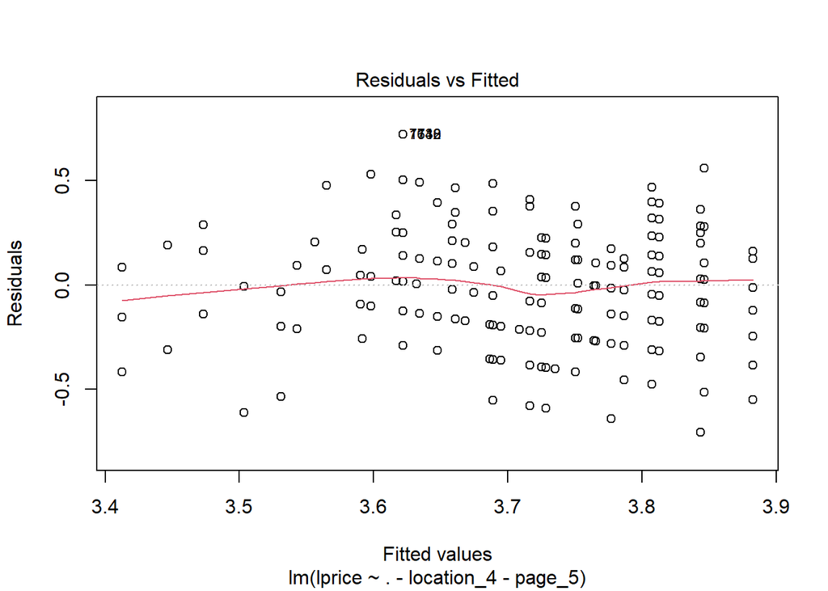

```r
#Linearity and Independence of Errors

plot(mod2, which = 1)
```

In the residuals versus fitted values plot, the points seem not totally randomly scattered, but it still appears not as a bad result.

**Normality of residuals**

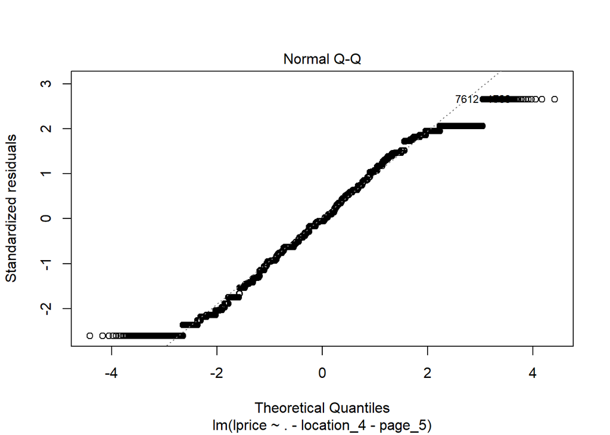

```r
plot(mod2, which = 2)
```

Most of the data points fall close to the line, but there does appear to be a flat curve and There is some data point that stand out.

#### f. Evaluate model on valid data set

```r
valid.df2<-dplyr::select(valid.df,lprice,location,modelphotography,page)
valid.df2_dummy<-fastDummies::dummy_cols(valid.df2,select_columns = c("location","modelphotography","page"),remove_first_dummy = T,remove_selected_columns = T)
head(valid.df2_dummy)
```

```
##     lprice location_2 location_3 location_4 location_5 location_6
## 1 3.496508          0          0          0          0          1
## 2 3.951244          1          0          0          0          0
## 3 3.637586          0          0          0          0          1
## 4 4.043051          0          0          0          0          0
## 5 3.871201          0          0          1          0          0
## 6 4.043051          0          1          0          0          0
##   modelphotography_2 page_2 page_3 page_4 page_5
## 1                  0      0      0      0      0
## 2                  0      0      0      0      0
## 3                  1      0      0      0      0
## 4                  1      0      0      1      0
## 5                  1      0      0      0      1
## 6                  0      1      0      0      0
```

```r
pred_training2 <- predict(mod2, data=train.df2_dummy, na.action=na.pass)
pred_valid2 <- predict(mod2, data=valid.df2_dummy, na.action=na.pass)
```

```r
## evaluate performance training
accuracy(pred_training2, train.df2_dummy$lprice)
```

```
##                     ME      RMSE       MAE        MPE     MAPE
## Test set -2.088765e-12 0.2713537 0.2187961 -0.5380763 5.917387
```

```r
## evaluate performance Validation
accuracy(pred_valid2, valid.df2_dummy$lprice)
```

```
##                    ME      RMSE       MAE       MPE     MAPE
## Test set 1.950346e-06 0.3053921 0.2481833 -0.612671 6.729169
```

### 3/ What customer’s attributes (where & when they buy) will affect the price ?

```r
train.df3<-dplyr::select(train.df,lprice,month,continent,weekday)
head(train.df3,3)
```

```
##          lprice month continent weekday
## 24388  4.127134     4    Europe  Monday
## 124413 3.496508     7   Website Tuesday
## 69586  3.496508     5    Europe  Monday
```

#### a. Create dummy variables for train.df1

```r
##create dummy for categorical variables
train.df3_dummy<-fastDummies::dummy_cols(train.df3,select_columns=c("month","continent","weekday"),remove_selected_columns = T,remove_first_dummy = T)

head(train.df3_dummy)
```

```
##     lprice month_5 month_6 month_7 month_8 continent_Europe
## 1 4.127134       0       0       0       0                1
## 2 3.496508       0       0       1       0                0
## 3 3.496508       1       0       0       0                1
## 4 3.761200       0       0       1       0                1
## 5 3.332205       0       0       0       0                1
## 6 2.995732       0       0       0       0                1
##   continent_NorthAmerica continent_Oceania continent_Website weekday_Monday
## 1                      0                 0                 0              1
## 2                      0                 0                 1              0
## 3                      0                 0                 0              1
## 4                      0                 0                 0              0
## 5                      0                 0                 0              1
## 6                      0                 0                 0              0
##   weekday_Saturday weekday_Sunday weekday_Thursday weekday_Tuesday
## 1                0              0                0               0
## 2                0              0                0               1
## 3                0              0                0               0
## 4                0              0                1               0
## 5                0              0                0               0
## 6                1              0                0               0
##   weekday_Wednesday
## 1                 0
## 2                 0
## 3                 0
## 4                 0
## 5                 0
## 6                 0
```

```r
mod3<-lm(lprice~.,data=train.df3_dummy)
summary(mod3)
```

```
##
## Call:
## lm(formula = lprice ~ ., data = train.df3_dummy)
##
## Residuals:
##      Min       1Q   Median       3Q      Max
## -0.88147 -0.23565  0.01896  0.21508  0.67666
##
## Coefficients:
##                          Estimate Std. Error t value Pr(>|t|)
## (Intercept)             3.6126415  0.1022244  35.340  < 2e-16 ***
## month_5                 0.0037545  0.0026190   1.434  0.15171
## month_6                 0.0035519  0.0026918   1.320  0.18699
## month_7                 0.0068222  0.0026182   2.606  0.00917 **
## month_8                 0.0074817  0.0035680   2.097  0.03600 *
## continent_Europe        0.1180965  0.1021920   1.156  0.24783
## continent_NorthAmerica  0.1554969  0.1057114   1.471  0.14131
## continent_Oceania      -0.1359801  0.2284851  -0.595  0.55175
## continent_Website       0.1453690  0.1023510   1.420  0.15552
## weekday_Monday          0.0102778  0.0034161   3.009  0.00263 **
## weekday_Saturday        0.0016679  0.0038017   0.439  0.66087
## weekday_Sunday          0.0014195  0.0036825   0.385  0.69988
## weekday_Thursday        0.0057480  0.0034216   1.680  0.09298 .
## weekday_Tuesday        -0.0006777  0.0033152  -0.204  0.83802
## weekday_Wednesday       0.0046821  0.0033349   1.404  0.16033
## ---
## Signif. codes:  0 '***' 0.001 '**' 0.01 '*' 0.05 '.' 0.1 ' ' 1
##
## Residual standard error: 0.289 on 99269 degrees of freedom
## Multiple R-squared:  0.000518,   Adjusted R-squared:  0.000377
## F-statistic: 3.675 on 14 and 99269 DF,  p-value: 3.499e-06
```

With the results above, we can conclude:

- Hypothesis test for whether all independent variables’ coefficient in the model equal to 0 or not - Ho: B1 + B2 + …+ Bk = 0. We see the F-statistic has p-value is 3.499e - 06 < 0.05, we can reject Ho, which means at least one independent variable has some effect on price (Or all independent variables’ coefficient together do not equal to 0).
- Hypothesis test for whether each independent variable’s coefficient in the model equals to 0 or not - Ho: Bk = 0. We see in the “Pr>(|t|)” column, only month_7, month_8, weekday_Monday have values < 0.05, their coefficients are significant at 95% confident interval; and weekday_Thursday has p-value (0.09298)< 0.1, its coefficient is just significant at 90% confident interval. The others have p-value quite large, we might consider to remove them out of the model.

```r
# Use stepAIC() to choose the better model
stepAIC(mod3)
```

```
## Start:  AIC=-246494
## lprice ~ month_5 + month_6 + month_7 + month_8 + continent_Europe +
##     continent_NorthAmerica + continent_Oceania + continent_Website +
##     weekday_Monday + weekday_Saturday + weekday_Sunday + weekday_Thursday +
##     weekday_Tuesday + weekday_Wednesday
##
##                          Df Sum of Sq    RSS     AIC
## - weekday_Tuesday         1   0.00349 8289.3 -246496
## - weekday_Sunday          1   0.01241 8289.3 -246496
## - weekday_Saturday        1   0.01607 8289.3 -246496
## - continent_Oceania       1   0.02958 8289.3 -246496
## - continent_Europe        1   0.11152 8289.4 -246495
## - month_6                 1   0.14540 8289.4 -246494
## - weekday_Wednesday       1   0.16459 8289.5 -246494
## <none>                                8289.3 -246494
## - continent_Website       1   0.16845 8289.5 -246494
## - month_5                 1   0.17160 8289.5 -246494
## - continent_NorthAmerica  1   0.18068 8289.5 -246494
## - weekday_Thursday        1   0.23565 8289.5 -246493
## - month_8                 1   0.36717 8289.7 -246492
## - month_7                 1   0.56697 8289.9 -246489
## - weekday_Monday          1   0.75585 8290.1 -246487
##
## Step:  AIC=-246496
## lprice ~ month_5 + month_6 + month_7 + month_8 + continent_Europe +
##     continent_NorthAmerica + continent_Oceania + continent_Website +
##     weekday_Monday + weekday_Saturday + weekday_Sunday + weekday_Thursday +
##     weekday_Wednesday
##
##                          Df Sum of Sq    RSS     AIC
## - weekday_Sunday          1   0.02659 8289.3 -246498
## - continent_Oceania       1   0.02962 8289.3 -246498
## - weekday_Saturday        1   0.03171 8289.3 -246498
## - continent_Europe        1   0.11134 8289.4 -246497
## - month_6                 1   0.14637 8289.5 -246496
## <none>                                8289.3 -246496
## - continent_Website       1   0.16818 8289.5 -246496
## - month_5                 1   0.17433 8289.5 -246496
## - continent_NorthAmerica  1   0.18048 8289.5 -246496
## - weekday_Wednesday       1   0.27873 8289.6 -246495
```

[output cut: 77 more lines]

```
##
## Step:  AIC=-246502.3
## lprice ~ month_7 + month_8 + continent_Europe + continent_NorthAmerica +
##     continent_Website + weekday_Monday + weekday_Thursday + weekday_Wednesday
##
##                          Df Sum of Sq    RSS     AIC
## <none>                                8289.6 -246502
## - continent_Europe        1   0.20954 8289.8 -246502
## - month_8                 1   0.21908 8289.8 -246502
## - weekday_Wednesday       1   0.21978 8289.8 -246502
## - continent_Website       1   0.29501 8289.9 -246501
## - continent_NorthAmerica  1   0.30587 8289.9 -246501
## - weekday_Thursday        1   0.35194 8290.0 -246500
## - month_7                 1   0.35270 8290.0 -246500
## - weekday_Monday          1   1.17007 8290.8 -246490
```

```
##
## Call:
## lm(formula = lprice ~ month_7 + month_8 + continent_Europe +
##     continent_NorthAmerica + continent_Website + weekday_Monday +
##     weekday_Thursday + weekday_Wednesday, data = train.df3_dummy)
##
## Coefficients:
##            (Intercept)                 month_7                 month_8
##               3.588475                0.004664                0.005379
##       continent_Europe  continent_NorthAmerica       continent_Website
##               0.144781                0.182425                0.172124
##         weekday_Monday        weekday_Thursday       weekday_Wednesday
##               0.009996                0.005495                0.004160
```

The stepAIC suggests: lprice ~ month_7 + month_8 + continent_Europe + continent_NorthAmerica + continent_Website + weekday_Monday + weekday_Thursday + weekday_Wednesday. (1)

We will compare 2 models- one is that stepAIC suggests and the other is lprice ~ month_7 + month_8 + weekday_Monday + weekday_Thursday

**Model (1)**

```r
mod3.1<-lm(lprice ~ month_7 + month_8 + continent_Europe + continent_NorthAmerica + continent_Website + weekday_Monday + weekday_Thursday + weekday_Wednesday,data=train.df3_dummy)
summary(mod3.1)
```

```
##
## Call:
## lm(formula = lprice ~ month_7 + month_8 + continent_Europe +
##     continent_NorthAmerica + continent_Website + weekday_Monday +
##     weekday_Thursday + weekday_Wednesday, data = train.df3_dummy)
##
## Residuals:
##      Min       1Q   Median       3Q      Max
## -0.88022 -0.23675  0.01841  0.21383  0.67346
##
## Coefficients:
##                        Estimate Std. Error t value Pr(>|t|)
## (Intercept)            3.588475   0.091407  39.258  < 2e-16 ***
## month_7                0.004664   0.002269   2.055 0.039862 *
## month_8                0.005379   0.003321   1.620 0.105288
## continent_Europe       0.144781   0.091396   1.584 0.113173
## continent_NorthAmerica 0.182425   0.095316   1.914 0.055635 .
## continent_Website      0.172124   0.091573   1.880 0.060161 .
## weekday_Monday         0.009996   0.002670   3.743 0.000182 ***
## weekday_Thursday       0.005495   0.002677   2.053 0.040076 *
## weekday_Wednesday      0.004160   0.002564   1.622 0.104727
## ---
## Signif. codes:  0 '***' 0.001 '**' 0.01 '*' 0.05 '.' 0.1 ' ' 1
##
## Residual standard error: 0.289 on 99275 degrees of freedom
## Multiple R-squared:  0.0004802,  Adjusted R-squared:  0.0003996
## F-statistic: 5.961 on 8 and 99275 DF,  p-value: 1.137e-07
```

**Model (2)**

```r
mod3.2<-lm(lprice ~ month_7 + month_8 + weekday_Monday + weekday_Thursday,data=train.df3_dummy)
summary(mod3.2)
```

```
##
## Call:
## lm(formula = lprice ~ month_7 + month_8 + weekday_Monday + weekday_Thursday,
##     data = train.df3_dummy)
##
## Residuals:
##      Min       1Q   Median       3Q      Max
## -0.85865 -0.23851  0.02109  0.21622  0.67170
##
## Coefficients:
##                  Estimate Std. Error  t value Pr(>|t|)
## (Intercept)      3.735021   0.001252 2983.426  < 2e-16 ***
## month_7          0.004713   0.002269    2.077 0.037821 *
## month_8          0.005084   0.003318    1.532 0.125489
## weekday_Monday   0.008920   0.002597    3.435 0.000593 ***
## weekday_Thursday 0.004430   0.002601    1.703 0.088564 .
## ---
## Signif. codes:  0 '***' 0.001 '**' 0.01 '*' 0.05 '.' 0.1 ' ' 1
##
## Residual standard error: 0.289 on 99279 degrees of freedom
## Multiple R-squared:  0.00019,    Adjusted R-squared:  0.0001497
## F-statistic: 4.717 on 4 and 99279 DF,  p-value: 0.0008347
```

#### e. Check L.I.N.E assumptions

**Checking for Multicolli` nearity (VIF test)**

*Model (1)*

```r
vif3.1<- tidy(vif(mod3.1))
kable(vif3.1,
caption="Variance product's attributes for the 'lprice' regression model",
col.names=c("regressor","VIF"))%>%
kable_styling(full_width = T)
```

Variance product’s attributes for the ‘lprice’ regression model

| regressor | VIF |
| --- | --- |
| month_7 | 1.028657 |
| month_8 | 1.032058 |
| continent_Europe | 256.223464 |
| continent_NorthAmerica | 12.389124 |
| continent_Website | 245.408839 |
| weekday_Monday | 1.093429 |
| weekday_Thursday | 1.100735 |
| weekday_Wednesday | 1.100267 |

The rule of thumb is that a regressor produces collinearity if its VIF is greater than 10, we see that all continent variables have values > 10, we might have to remove them.

```r
mod3.1<-lm(lprice ~ month_7 + month_8 + continent_NorthAmerica + continent_Europe+ weekday_Monday + weekday_Thursday + weekday_Wednesday,data=train.df3_dummy)
summary(mod3.1)
```

```
##
## Call:
## lm(formula = lprice ~ month_7 + month_8 + continent_NorthAmerica +
##     continent_Europe + weekday_Monday + weekday_Thursday + weekday_Wednesday,
##     data = train.df3_dummy)
##
## Residuals:
##      Min       1Q   Median       3Q      Max
## -0.87950 -0.23677  0.01839  0.21382  0.67345
##
## Coefficients:
##                         Estimate Std. Error t value Pr(>|t|)
## (Intercept)             3.759934   0.005855 642.132  < 2e-16 ***
## month_7                 0.004626   0.002269   2.038 0.041503 *
## month_8                 0.005390   0.003321   1.623 0.104576
## continent_NorthAmerica  0.010984   0.027674   0.397 0.691439
## continent_Europe       -0.026660   0.005835  -4.569  4.9e-06 ***
## weekday_Monday          0.009933   0.002670   3.720 0.000199 ***
## weekday_Thursday        0.005504   0.002677   2.056 0.039775 *
## weekday_Wednesday       0.004146   0.002564   1.617 0.105876
## ---
## Signif. codes:  0 '***' 0.001 '**' 0.01 '*' 0.05 '.' 0.1 ' ' 1
##
## Residual standard error: 0.289 on 99276 degrees of freedom
## Multiple R-squared:  0.0004446,  Adjusted R-squared:  0.0003741
## F-statistic: 6.308 on 7 and 99276 DF,  p-value: 2.001e-07
```

```r
vif3.1<- tidy(vif(mod3.1))
kable(vif3.1,
caption="Variance product's attributes for the 'lprice' regression model",
col.names=c("regressor","VIF"))%>%
kable_styling(full_width = T)
```

Variance product’s attributes for the ‘lprice’ regression model

| regressor | VIF |
| --- | --- |
| month_7 | 1.028575 |
| month_8 | 1.032055 |
| continent_NorthAmerica | 1.044329 |
| continent_Europe | 1.044201 |
| weekday_Monday | 1.093255 |
| weekday_Thursday | 1.100732 |
| weekday_Wednesday | 1.100259 |

After removing the continent_Website, all VIF values look better (under 10)

```r
vif3.2<- tidy(vif(mod3.2))

kable(vif3.2,
caption="Variance product's attributes for the 'lprice' regression model",
col.names=c("regressor","VIF"))%>%
kable_styling(full_width = T)
```

Variance product’s attributes for the ‘lprice’ regression model

| regressor | VIF |
| --- | --- |
| month_7 | 1.028296 |
| month_8 | 1.030288 |
| weekday_Monday | 1.033831 |
| weekday_Thursday | 1.039176 |

The rule of thumb is that a regressor produces collinearity if its VIF is greater than 10 . All our regressors have VIF coefficient less than 10, so there is no multicollinearity between each independent variables!

**Heteroscedasticity (breusch pagan test - bptest)**

```r
bptest(mod3.1)
```

```
##
##  studentized Breusch-Pagan test
##
## data:  mod3.1
## BP = 18.772, df = 7, p-value = 0.008931
```

```r
bptest(mod3.2)
```

```
##
##  studentized Breusch-Pagan test
##
## data:  mod3.2
## BP = 14.388, df = 4, p-value = 0.006154
```

**Linearity and Independence of Errors**

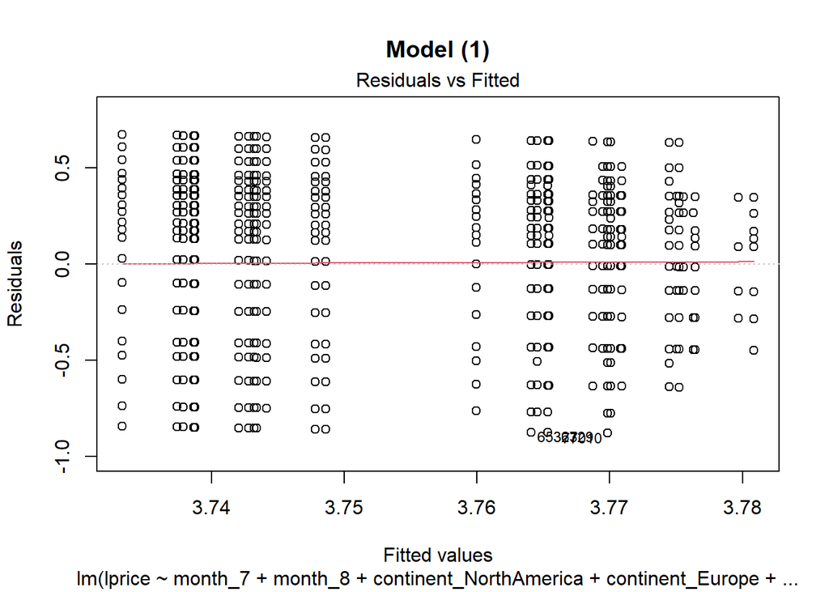

```r
#Linearity and Independence of Errors

plot(mod3.1, which = 1, main = "Model (1)")
```

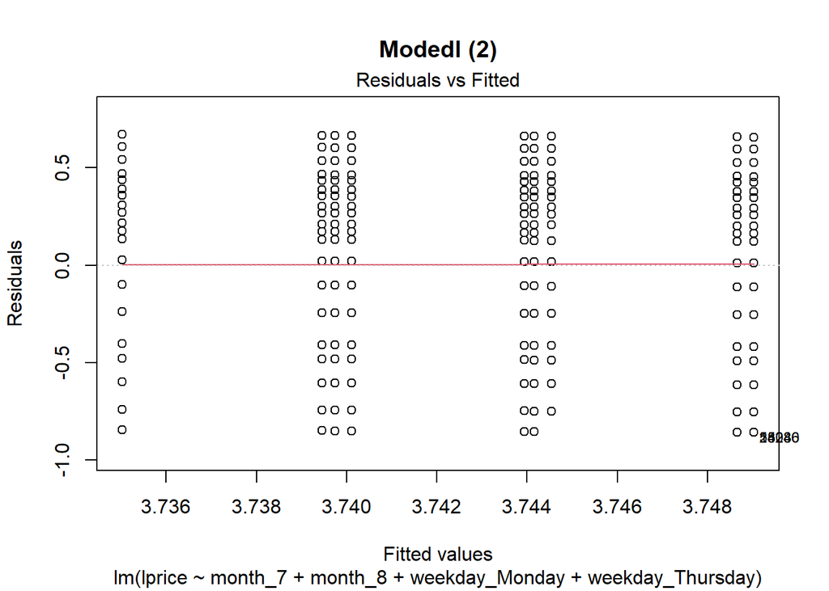

```r
plot(mod3.2, which = 1, main = "Modedl (2)")
```

In the residuals versus fitted values plot, the points seem not totally randomly scattered

**Normality of residuals**

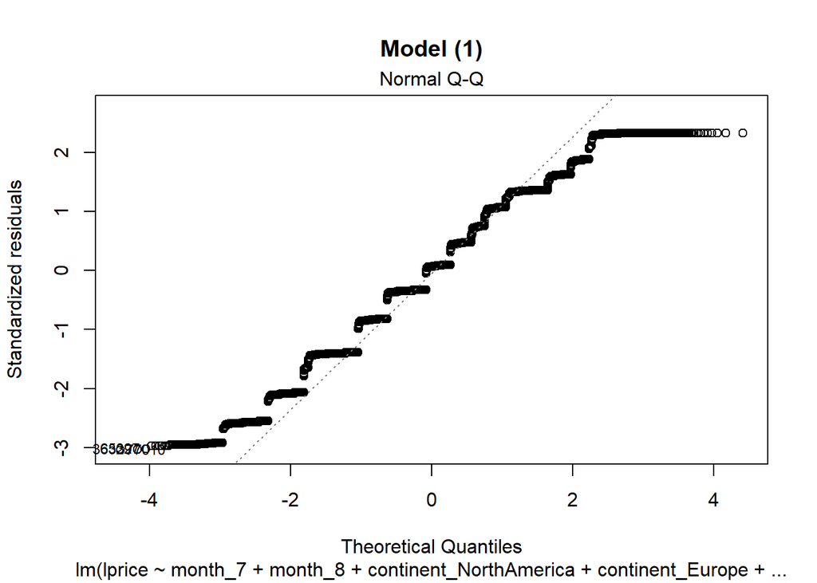

```r
plot(mod3.1, which = 2,main = "Model (1)")
```

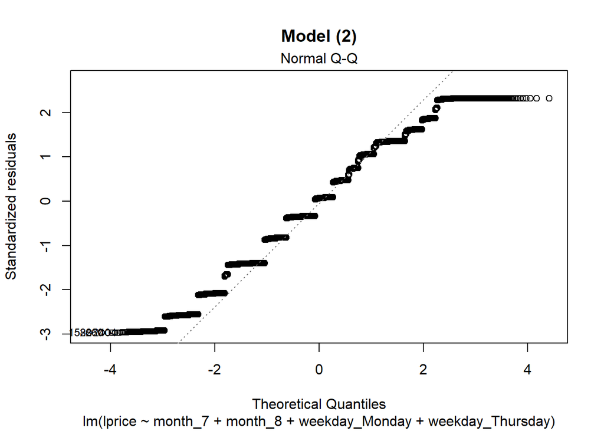

```r
plot(mod3.2, which = 2,main = "Model (2)")
```

Most of the data points fall close to the line, but there does appear to be a flat curve and There is some data point that stand out.

#### f. Evaluate model on valid data set

```r
valid.df3<-dplyr::select(valid.df,lprice,month,continent,weekday)
valid.df3_dummy<-fastDummies::dummy_cols(valid.df3,select_columns = c("month","continent","weekday"),remove_first_dummy = T,remove_selected_columns = T)
head(valid.df3_dummy)
```

```
##     lprice month_5 month_6 month_7 month_8 continent_Europe
## 1 3.496508       0       0       0       0                1
## 2 3.951244       0       0       0       0                1
## 3 3.637586       0       0       0       0                1
## 4 4.043051       0       0       0       0                1
## 5 3.871201       0       0       0       0                1
## 6 4.043051       0       0       0       0                1
##   continent_NorthAmerica continent_Oceania continent_Website weekday_Monday
## 1                      0                 0                 0              0
## 2                      0                 0                 0              0
## 3                      0                 0                 0              0
## 4                      0                 0                 0              0
## 5                      0                 0                 0              0
## 6                      0                 0                 0              0
##   weekday_Saturday weekday_Sunday weekday_Thursday weekday_Tuesday
## 1                0              0                0               1
## 2                0              0                0               1
## 3                0              0                0               1
## 4                0              0                0               1
## 5                0              0                0               1
## 6                0              0                0               1
##   weekday_Wednesday
## 1                 0
## 2                 0
## 3                 0
## 4                 0
## 5                 0
## 6                 0
```

**Model (1)**

```r
pred_training3.1 <- predict(mod3.1, data=train.df3_dummy, na.action=na.pass)
pred_valid3.1 <- predict(mod3.1, data=valid.df3_dummy, na.action=na.pass)
```

```r
## evaluate performance training
accuracy(pred_training3.1, train.df3_dummy$lprice)
```

```
##                     ME      RMSE       MAE        MPE     MAPE
## Test set -2.088792e-12 0.2889584 0.2355503 -0.6129468 6.388636
```

```r
## evaluate performance Validation
accuracy(pred_valid3.1, valid.df3_dummy$lprice)
```

```
##                    ME      RMSE       MAE        MPE     MAPE
## Test set 0.0001276254 0.2891145 0.2355649 -0.6100841 6.389393
```

**Model (2)**

```r
pred_training3.2 <- predict(mod3.2, data=train.df3_dummy, na.action=na.pass)
pred_valid3.2 <- predict(mod3.2, data=valid.df3_dummy, na.action=na.pass)
```

```r
## evaluate performance training
accuracy(pred_training3.2, train.df3_dummy$lprice)
```

```
##                     ME      RMSE       MAE        MPE     MAPE
## Test set -2.087283e-12 0.2889952 0.2356036 -0.6131035 6.390095
```

```r
## evaluate performance Validation
accuracy(pred_valid3.2, valid.df3_dummy$lprice)
```

```
##                    ME      RMSE       MAE        MPE     MAPE
## Test set 0.0001309757 0.2890976 0.2355627 -0.6100377 6.389351
```

### 4/ Which attributes will affect the price ?

```r
train.df4<-dplyr::select(train.df,lprice,page1maincategory, colour,location,modelphotography,page,month,continent,weekday)
head(train.df4,3)
```

```
##          lprice page1maincategory colour location modelphotography page month
## 24388  4.127134                 2     12        5                2    1     4
## 124413 3.496508                 3      6        2                1    1     7
## 69586  3.496508                 1     14        5                2    1     5
##        continent weekday
## 24388     Europe  Monday
## 124413   Website Tuesday
## 69586     Europe  Monday
```

#### a. Create dummy variables for train.df4

```r
##create dummy for categorical variables
train.df4_dummy<-fastDummies::dummy_cols(train.df4,select_columns=c("colour","page1maincategory","location","modelphotography","page","month","continent","weekday"),remove_selected_columns = T,remove_first_dummy = T)

head(train.df4_dummy)
```

```
##     lprice colour_2 colour_3 colour_4 colour_5 colour_6 colour_7 colour_8
## 1 4.127134        0        0        0        0        0        0        0
## 2 3.496508        0        0        0        0        1        0        0
## 3 3.496508        0        0        0        0        0        0        0
## 4 3.761200        0        1        0        0        0        0        0
## 5 3.332205        0        0        0        0        0        0        0
## 6 2.995732        0        0        0        0        0        0        0
##   colour_9 colour_10 colour_11 colour_12 colour_13 colour_14
## 1        0         0         0         1         0         0
## 2        0         0         0         0         0         0
## 3        0         0         0         0         0         1
## 4        0         0         0         0         0         0
## 5        0         0         0         0         1         0
## 6        1         0         0         0         0         0
##   page1maincategory_2 page1maincategory_3 page1maincategory_4 location_2
```

[output cut: 41 more lines]

```r
mod4<-lm(lprice~.,data=train.df4_dummy)
summary(mod4)
```

```
##
## Call:
## lm(formula = lprice ~ ., data = train.df4_dummy)
##
## Residuals:
##      Min       1Q   Median       3Q      Max
## -0.52248 -0.18119 -0.00468  0.18554  0.74340
##
## Coefficients:
##                          Estimate Std. Error t value Pr(>|t|)
## (Intercept)             3.4944657  0.0804437  43.440  < 2e-16 ***
## colour_2                0.2478488  0.0040023  61.927  < 2e-16 ***
## colour_3                0.2739811  0.0040280  68.019  < 2e-16 ***
## colour_4                0.2105301  0.0043813  48.051  < 2e-16 ***
## colour_5                0.1311427  0.0086659  15.133  < 2e-16 ***
## colour_6                0.1253519  0.0043574  28.768  < 2e-16 ***
## colour_7                0.0198154  0.0053124   3.730 0.000192 ***
## colour_8               -0.2903963  0.0068433 -42.435  < 2e-16 ***
## colour_9                0.1656835  0.0047089  35.185  < 2e-16 ***
## colour_10               0.2933632  0.0067769  43.289  < 2e-16 ***
## colour_11               0.3255057  0.0057982  56.139  < 2e-16 ***
## colour_12               0.2560137  0.0049701  51.511  < 2e-16 ***
## colour_13               0.0592492  0.0054449  10.882  < 2e-16 ***
## colour_14               0.1928273  0.0044646  43.190  < 2e-16 ***
## page1maincategory_2     0.0983951  0.0025689  38.303  < 2e-16 ***
## page1maincategory_3    -0.1262165  0.0026351 -47.899  < 2e-16 ***
## page1maincategory_4    -0.2455804  0.0024607 -99.800  < 2e-16 ***
## location_2             -0.1035839  0.0025057 -41.340  < 2e-16 ***
## location_3              0.0206889  0.0026507   7.805 6.01e-15 ***
## location_4             -0.0531942  0.0026212 -20.294  < 2e-16 ***
## location_5             -0.1082513  0.0027668 -39.125  < 2e-16 ***
## location_6             -0.0263010  0.0028692  -9.167  < 2e-16 ***
## modelphotography_2     -0.0893475  0.0018733 -47.696  < 2e-16 ***
## page_2                  0.0628619  0.0019705  31.901  < 2e-16 ***
## page_3                 -0.0546668  0.0026513 -20.619  < 2e-16 ***
## page_4                  0.1412116  0.0039102  36.114  < 2e-16 ***
## page_5                  0.2564260  0.0060931  42.085  < 2e-16 ***
## month_5                -0.0055689  0.0020596  -2.704 0.006855 **
## month_6                -0.0050307  0.0021164  -2.377 0.017455 *
## month_7                 0.0034320  0.0020623   1.664 0.096091 .
## month_8                 0.0092654  0.0028117   3.295 0.000984 ***
## continent_Europe        0.1698517  0.0803099   2.115 0.034436 *
## continent_NorthAmerica  0.1799679  0.0830758   2.166 0.030290 *
## continent_Oceania       0.0298894  0.1795564   0.166 0.867793
## continent_Website       0.1733004  0.0804346   2.155 0.031199 *
## weekday_Monday          0.0014068  0.0026852   0.524 0.600328
## weekday_Saturday        0.0006563  0.0029877   0.220 0.826125
## weekday_Sunday         -0.0028139  0.0028943  -0.972 0.330951
## weekday_Thursday       -0.0019091  0.0026894  -0.710 0.477781
## weekday_Tuesday        -0.0027905  0.0026057  -1.071 0.284207
## weekday_Wednesday       0.0012847  0.0026212   0.490 0.624055
## ---
## Signif. codes:  0 '***' 0.001 '**' 0.01 '*' 0.05 '.' 0.1 ' ' 1
##
## Residual standard error: 0.227 on 99243 degrees of freedom
## Multiple R-squared:  0.3831, Adjusted R-squared:  0.3829
## F-statistic:  1541 on 40 and 99243 DF,  p-value: < 2.2e-16
```

With the results above, we can conclude:

- Hypothesis test for whether all independent variables’ coefficient in the model equal to 0 or not - Ho: B1 + B2 + …+ Bk = 0. We see the F-statistic has p-value < 2.2e - 16, we can reject Ho, which means at least one independent variable has some effect on price (Or all independent variables’ coefficient together do not equal to 0).
- Hypothesis test for whether each independent variable’s coefficient in the model equals to 0 or not - Ho: Bk = 0. We see in the “Pr>(|t|)” column, most of values are <2e-16 <0.05, we can reject Ho of those values, which means they have significant effect on price - their coefficients do not equal to 0 and they are significant at confident interval 95%; Month_7 have p-value <0.1, their coefficient are still significant at confident interval 90%. Others: continent_Oceania & weekday have p-values are very high, we might consider to exclude them out of the model.

```r
# Use stepAIC() to choose the better model
stepAIC(mod4)
```

```
## Start:  AIC=-294353.8
## lprice ~ colour_2 + colour_3 + colour_4 + colour_5 + colour_6 +
##     colour_7 + colour_8 + colour_9 + colour_10 + colour_11 +
##     colour_12 + colour_13 + colour_14 + page1maincategory_2 +
##     page1maincategory_3 + page1maincategory_4 + location_2 +
##     location_3 + location_4 + location_5 + location_6 + modelphotography_2 +
##     page_2 + page_3 + page_4 + page_5 + month_5 + month_6 + month_7 +
##     month_8 + continent_Europe + continent_NorthAmerica + continent_Oceania +
##     continent_Website + weekday_Monday + weekday_Saturday + weekday_Sunday +
##     weekday_Thursday + weekday_Tuesday + weekday_Wednesday
##
##                          Df Sum of Sq    RSS     AIC
## - continent_Oceania       1      0.00 5116.1 -294356
## - weekday_Saturday        1      0.00 5116.1 -294356
## - weekday_Wednesday       1      0.01 5116.1 -294356
## - weekday_Monday          1      0.01 5116.1 -294356
## - weekday_Thursday        1      0.03 5116.1 -294355
## - weekday_Sunday          1      0.05 5116.2 -294355
## - weekday_Tuesday         1      0.06 5116.2 -294355
## <none>                                5116.1 -294354
## - month_7                 1      0.14 5116.2 -294353
## - continent_Europe        1      0.23 5116.3 -294351
## - continent_Website       1      0.24 5116.3 -294351
## - continent_NorthAmerica  1      0.24 5116.3 -294351
## - month_6                 1      0.29 5116.4 -294350
## - month_5                 1      0.38 5116.5 -294348
## - month_8                 1      0.56 5116.7 -294345
## - colour_7                1      0.72 5116.8 -294342
## - location_3              1      3.14 5119.2 -294295
## - location_6              1      4.33 5120.4 -294272
## - colour_13               1      6.10 5122.2 -294237
## - colour_5                1     11.81 5127.9 -294127
## - location_4              1     21.23 5137.3 -293945
## - page_3                  1     21.92 5138.0 -293931
## - colour_6                1     42.66 5158.8 -293531
## - page_2                  1     52.46 5168.6 -293343
## - colour_9                1     63.82 5179.9 -293125
## - page_4                  1     67.23 5183.3 -293060
## - page1maincategory_2     1     75.63 5191.7 -292899
## - location_5              1     78.91 5195.0 -292836
```

[output cut: 342 more lines]

```
## - page1maincategory_2     1     75.59 5192.0 -292908
## - location_5              1     78.92 5195.3 -292844
## - location_2              1     88.10 5204.5 -292669
## - page_5                  1     91.32 5207.7 -292607
## - colour_8                1     92.86 5209.3 -292578
## - colour_14               1     96.18 5212.6 -292515
## - colour_10               1     96.63 5213.0 -292506
## - modelphotography_2      1    117.30 5233.7 -292113
## - page1maincategory_3     1    118.36 5234.8 -292093
## - colour_4                1    119.08 5235.5 -292080
## - colour_12               1    136.86 5253.3 -291743
## - colour_11               1    162.48 5278.9 -291260
## - colour_2                1    197.73 5314.1 -290599
## - colour_3                1    238.56 5355.0 -289839
## - page1maincategory_4     1    513.66 5630.1 -284866
```

```
##
## Call:
## lm(formula = lprice ~ colour_2 + colour_3 + colour_4 + colour_5 +
##     colour_6 + colour_7 + colour_8 + colour_9 + colour_10 + colour_11 +
##     colour_12 + colour_13 + colour_14 + page1maincategory_2 +
##     page1maincategory_3 + page1maincategory_4 + location_2 +
##     location_3 + location_4 + location_5 + location_6 + modelphotography_2 +
##     page_2 + page_3 + page_4 + page_5 + month_5 + month_6 + month_7 +
##     month_8 + continent_Europe + continent_NorthAmerica + continent_Website,
##     data = train.df4_dummy)
##
## Coefficients:
##            (Intercept)                colour_2                colour_3
##               3.501668                0.247853                0.274003
##               colour_4                colour_5                colour_6
##               0.210559                0.131244                0.125365
##               colour_7                colour_8                colour_9
##               0.019793               -0.290440                0.165659
##              colour_10               colour_11               colour_12
##               0.293389                0.325501                0.256065
##              colour_13               colour_14     page1maincategory_2
##               0.059239                0.192834                0.098366
##    page1maincategory_3     page1maincategory_4              location_2
##              -0.126245               -0.245596               -0.103580
##             location_3              location_4              location_5
##               0.020653               -0.053202               -0.108258
##             location_6      modelphotography_2                  page_2
##              -0.026281               -0.089350                0.062855
##                 page_3                  page_4                  page_5
##              -0.054652                0.141211                0.256444
##                month_5                 month_6                 month_7
##              -0.005572               -0.005085                0.003298
##                month_8        continent_Europe  continent_NorthAmerica
##               0.009290                0.162104                0.172053
##      continent_Website
##               0.165403
```

The stepAIC suggests: lprice ~ lprice ~ colour_2 + colour_3 + colour_4 + colour_5 + colour_6 + colour_7 + colour_8 + colour_9 + colour_10 + colour_11 + colour_12 + colour_13 + colour_14 + page1maincategory_2 + page1maincategory_3 + page1maincategory_4 + location_2 + location_3 + location_4 + location_5 + location_6 + modelphotography_2 + page_2 + page_3 + page_4 + page_5 + month_5 + month_6 + month_7 + month_8 + continent_Europe + continent_NorthAmerica + continent_Website,

```r
mod4<-lm(lprice ~ colour_2 + colour_3 + colour_4 + colour_5 +
    colour_6 + colour_7 + colour_8 + colour_9 + colour_10 + colour_11 +
    colour_12 + colour_13 + colour_14 + page1maincategory_2 +
    page1maincategory_3 + page1maincategory_4 + location_2 +
    location_3 + location_4 + location_5 + location_6 + modelphotography_2 +
    page_2 + page_3 + page_4 + page_5 + month_5 + month_6 + month_7 +
    month_8 + continent_Europe + continent_NorthAmerica + continent_Website,,data=train.df4_dummy)
summary(mod4)
```

```
##
## Call:
## lm(formula = lprice ~ colour_2 + colour_3 + colour_4 + colour_5 +
##     colour_6 + colour_7 + colour_8 + colour_9 + colour_10 + colour_11 +
##     colour_12 + colour_13 + colour_14 + page1maincategory_2 +
##     page1maincategory_3 + page1maincategory_4 + location_2 +
##     location_3 + location_4 + location_5 + location_6 + modelphotography_2 +
##     page_2 + page_3 + page_4 + page_5 + month_5 + month_6 + month_7 +
##     month_8 + continent_Europe + continent_NorthAmerica + continent_Website,
##     data = train.df4_dummy)
##
## Residuals:
##     Min      1Q  Median      3Q     Max
## -0.5218 -0.1799 -0.0040  0.1850  0.7411
##
## Coefficients:
##                         Estimate Std. Error t value Pr(>|t|)
## (Intercept)             3.501668   0.071954  48.665  < 2e-16 ***
## colour_2                0.247853   0.004002  61.933  < 2e-16 ***
## colour_3                0.274003   0.004028  68.027  < 2e-16 ***
## colour_4                0.210559   0.004381  48.061  < 2e-16 ***
## colour_5                0.131244   0.008666  15.145  < 2e-16 ***
## colour_6                0.125365   0.004357  28.772  < 2e-16 ***
## colour_7                0.019793   0.005312   3.726 0.000195 ***
## colour_8               -0.290440   0.006843 -42.443  < 2e-16 ***
## colour_9                0.165659   0.004709  35.182  < 2e-16 ***
## colour_10               0.293389   0.006777  43.294  < 2e-16 ***
## colour_11               0.325501   0.005798  56.141  < 2e-16 ***
## colour_12               0.256065   0.004970  51.525  < 2e-16 ***
## colour_13               0.059239   0.005445  10.880  < 2e-16 ***
## colour_14               0.192834   0.004464  43.194  < 2e-16 ***
## page1maincategory_2     0.098366   0.002569  38.294  < 2e-16 ***
## page1maincategory_3    -0.126245   0.002635 -47.916  < 2e-16 ***
## page1maincategory_4    -0.245596   0.002460 -99.820  < 2e-16 ***
## location_2             -0.103580   0.002506 -41.339  < 2e-16 ***
## location_3              0.020653   0.002651   7.792 6.68e-15 ***
## location_4             -0.053202   0.002621 -20.298  < 2e-16 ***
## location_5             -0.108258   0.002767 -39.127  < 2e-16 ***
## location_6             -0.026281   0.002869  -9.160  < 2e-16 ***
## modelphotography_2     -0.089350   0.001873 -47.701  < 2e-16 ***
## page_2                  0.062855   0.001970  31.902  < 2e-16 ***
## page_3                 -0.054652   0.002651 -20.615  < 2e-16 ***
## page_4                  0.141211   0.003910  36.118  < 2e-16 ***
## page_5                  0.256444   0.006093  42.090  < 2e-16 ***
## month_5                -0.005572   0.002053  -2.713 0.006661 **
## month_6                -0.005085   0.002111  -2.409 0.015977 *
## month_7                 0.003298   0.002058   1.602 0.109149
## month_8                 0.009290   0.002803   3.314 0.000921 ***
## continent_Europe        0.162104   0.071818   2.257 0.024000 *
## continent_NorthAmerica  0.172053   0.074902   2.297 0.021618 *
## continent_Website       0.165403   0.071957   2.299 0.021528 *
## ---
## Signif. codes:  0 '***' 0.001 '**' 0.01 '*' 0.05 '.' 0.1 ' ' 1
##
## Residual standard error: 0.227 on 99250 degrees of freedom
## Multiple R-squared:  0.3831, Adjusted R-squared:  0.3829
## F-statistic:  1868 on 33 and 99250 DF,  p-value: < 2.2e-16
```

#### e. Check L.I.N.E assumptions

**Checking for Multicollinearity (VIF test)**

```r
vif4<- tidy(vif(mod4))
kable(vif4,
caption="Variance product's attributes for the 'lprice' regression model",
col.names=c("regressor","VIF"))%>%
kable_styling(full_width = T)
```

Variance product’s attributes for the ‘lprice’ regression model

| regressor | VIF |
| --- | --- |
| colour_2 | 4.554500 |
| colour_3 | 4.549528 |
| colour_4 | 3.325593 |
| colour_5 | 1.434897 |
| colour_6 | 3.473392 |
| colour_7 | 2.175282 |
| colour_8 | 1.454573 |
| colour_9 | 3.193316 |
| colour_10 | 1.814087 |
| colour_11 | 2.014577 |
| colour_12 | 2.436616 |
| colour_13 | 2.048346 |
| colour_14 | 3.323980 |
| page1maincategory_2 | 2.270471 |
| page1maincategory_3 | 2.386541 |
| page1maincategory_4 | 2.084512 |
| location_2 | 1.942999 |
| location_3 | 1.550804 |
| location_4 | 1.819681 |
| location_5 | 2.062580 |
| location_6 | 1.734161 |
| modelphotography_2 | 1.298053 |
| page_2 | 1.393987 |
| page_3 | 1.394900 |
| page_4 | 1.477036 |
| page_5 | 1.204628 |
| month_5 | 1.366950 |
| month_6 | 1.346542 |
| month_7 | 1.370866 |
| month_8 | 1.191425 |
| continent_Europe | 256.263523 |
| continent_NorthAmerica | 12.392431 |
| continent_Website | 245.447964 |

The rule of thumb is that a regressor produces collinearity if its VIF is greater than 10, we see that all continent variables have values > 10, we might have to remove them.

```r
mod4<-lm(lprice ~ colour_2 + colour_3 + colour_4 + colour_5 +
    colour_6 + colour_7 + colour_8 + colour_9 + colour_10 + colour_11 +
    colour_12 + colour_13 + colour_14 + page1maincategory_2 +
    page1maincategory_3 + page1maincategory_4 + location_2 +
    location_3 + location_4 + location_5 + location_6 + modelphotography_2 +
    page_2 + page_3 + page_4 + page_5 + month_5 + month_6 + month_7 +
    month_8 + continent_Europe + continent_NorthAmerica,data=train.df4_dummy)
vif4<- tidy(vif(mod4))
kable(vif4,
caption="Variance product's attributes for the 'lprice' regression model",
col.names=c("regressor","VIF"))%>%
kable_styling(full_width = T)
```

Variance product’s attributes for the ‘lprice’ regression model

| regressor | VIF |
| --- | --- |
| colour_2 | 4.554500 |
| colour_3 | 4.549526 |
| colour_4 | 3.325592 |
| colour_5 | 1.434893 |
| colour_6 | 3.473356 |
| colour_7 | 2.175279 |
| colour_8 | 1.454573 |
| colour_9 | 3.193314 |
| colour_10 | 1.814087 |
| colour_11 | 2.014534 |
| colour_12 | 2.436613 |
| colour_13 | 2.048323 |
| colour_14 | 3.323976 |
| page1maincategory_2 | 2.270447 |
| page1maincategory_3 | 2.386424 |
| page1maincategory_4 | 2.084502 |
| location_2 | 1.942997 |
| location_3 | 1.550796 |
| location_4 | 1.819665 |
| location_5 | 2.062579 |
| location_6 | 1.734160 |
| modelphotography_2 | 1.298044 |
| page_2 | 1.393866 |
| page_3 | 1.394874 |
| page_4 | 1.477036 |
| page_5 | 1.204628 |
| month_5 | 1.366938 |
| month_6 | 1.346534 |
| month_7 | 1.370738 |
| month_8 | 1.191425 |
| continent_Europe | 1.047476 |
| continent_NorthAmerica | 1.046001 |

After removing the continent_Website, all VIF values look better (under 10)

**Heteroscedasticity (breusch pagan test - bptest)**

```r
bptest(mod4)
```

```
##
##  studentized Breusch-Pagan test
##
## data:  mod4
## BP = 16615, df = 32, p-value < 2.2e-16
```

**Linearity and Independence of Errors**

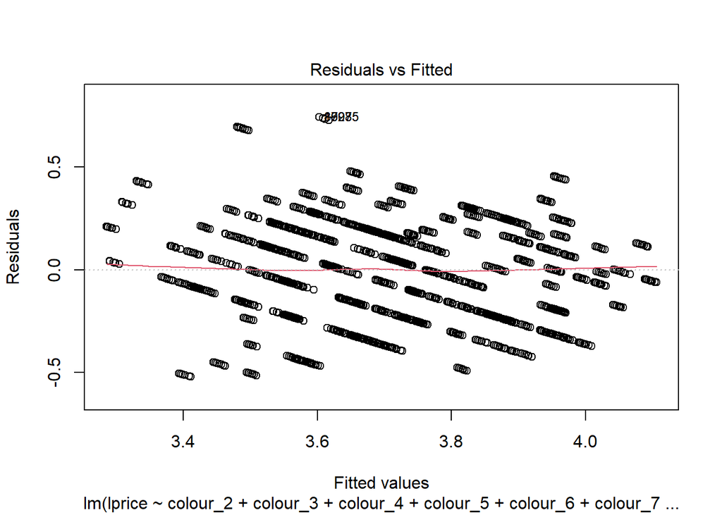

```r
#Linearity and Independence of Errors

plot(mod4, which = 1)
```

In the residuals versus fitted values plot, the points seem not totally randomly scattered

**Normality of residuals**

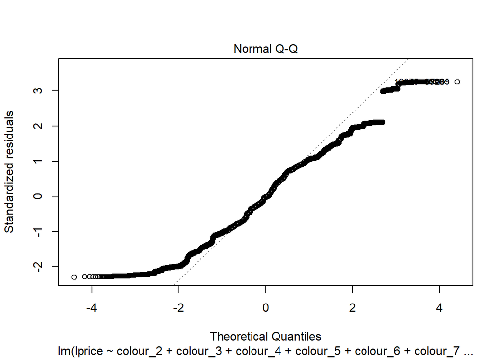

```r
plot(mod4, which = 2)
```

Most of the data points fall close to the line, but there does appear to be a flat curve and There is some data point that stand out.

#### f. Evaluate model on valid data set

```r
valid.df4<-dplyr::select(valid.df,lprice, page1maincategory, colour,location,modelphotography,page,month,continent,weekday)
valid.df4_dummy<-fastDummies::dummy_cols(valid.df4,select_columns = c("colour","page1maincategory","location","modelphotography","page","month","continent","weekday"),remove_first_dummy = T,remove_selected_columns = T)
head(valid.df4_dummy)
```

```
##     lprice colour_2 colour_3 colour_4 colour_5 colour_6 colour_7 colour_8
## 1 3.496508        0        0        0        0        0        0        0
## 2 3.951244        0        0        0        0        0        0        0
## 3 3.637586        0        0        0        0        1        0        0
## 4 4.043051        0        0        0        0        1        0        0
## 5 3.871201        0        0        0        0        1        0        0
## 6 4.043051        1        0        0        0        0        0        0
##   colour_9 colour_10 colour_11 colour_12 colour_13 colour_14
## 1        0         0         0         0         0         0
## 2        0         1         0         0         0         0
## 3        0         0         0         0         0         0
## 4        0         0         0         0         0         0
## 5        0         0         0         0         0         0
## 6        0         0         0         0         0         0
##   page1maincategory_2 page1maincategory_3 page1maincategory_4 location_2
```

[output cut: 41 more lines]

```r
pred_training4<- predict(mod4, data=train.df4_dummy, na.action=na.pass)
pred_valid4 <- predict(mod4, data=valid.df4_dummy, na.action=na.pass)
```

```r
## evaluate performance training
accuracy(pred_training4, train.df4_dummy$lprice)
```

```
##                     ME     RMSE      MAE        MPE     MAPE
## Test set -2.087567e-12 0.227015 0.191068 -0.3774187 5.166034
```

```r
## evaluate performance Validation
accuracy(pred_valid4, valid.df4_dummy$lprice)
```

```
##                    ME    RMSE       MAE        MPE     MAPE
## Test set 0.0003925978 0.33954 0.2746275 -0.6020399 7.438368
```

#### 5/ Test one that gives us high accuracy rate in business question 2.

```r
mod4<-lm(lprice~page1maincategory_2+page1maincategory_3+
                location_3+ location_5+location_6+modelphotography_2+page_2+page_3+page_4+
                month_5+month_6+month_7+month_8+colour_2+colour_3+colour_4+colour_5+colour_6+colour_7+colour_8+colour_9+colour_10+colour_11+colour_12+colour_13+colour_14, data=train.df4_dummy)
summary(mod4)
```

```
##
## Call:
## lm(formula = lprice ~ page1maincategory_2 + page1maincategory_3 +
##     location_3 + location_5 + location_6 + modelphotography_2 +
##     page_2 + page_3 + page_4 + month_5 + month_6 + month_7 +
##     month_8 + colour_2 + colour_3 + colour_4 + colour_5 + colour_6 +
##     colour_7 + colour_8 + colour_9 + colour_10 + colour_11 +
##     colour_12 + colour_13 + colour_14, data = train.df4_dummy)
##
## Residuals:
##      Min       1Q   Median       3Q      Max
## -0.72023 -0.17151 -0.01988  0.16293  0.77074
##
## Coefficients:
##                       Estimate Std. Error t value Pr(>|t|)
## (Intercept)          3.5950136  0.0040910 878.766  < 2e-16 ***
## page1maincategory_2  0.2145611  0.0023235  92.344  < 2e-16 ***
## page1maincategory_3  0.0116831  0.0022541   5.183 2.19e-07 ***
## location_3           0.0586947  0.0023887  24.572  < 2e-16 ***
## location_5          -0.0511493  0.0023959 -21.348  < 2e-16 ***
## location_6           0.0195746  0.0025546   7.662 1.84e-14 ***
## modelphotography_2  -0.1022383  0.0019541 -52.319  < 2e-16 ***
## page_2               0.0714635  0.0020339  35.136  < 2e-16 ***
## page_3              -0.0726207  0.0027469 -26.438  < 2e-16 ***
## page_4               0.0657771  0.0039727  16.557  < 2e-16 ***
## month_5             -0.0005411  0.0021710  -0.249  0.80317
## month_6             -0.0015264  0.0022319  -0.684  0.49403
## month_7              0.0046348  0.0021760   2.130  0.03318 *
## month_8              0.0085800  0.0029634   2.895  0.00379 **
## colour_2             0.1451199  0.0040789  35.578  < 2e-16 ***
## colour_3             0.2521355  0.0042257  59.667  < 2e-16 ***
## colour_4             0.0747986  0.0044286  16.890  < 2e-16 ***
## colour_5             0.0606077  0.0091276   6.640 3.15e-11 ***
## colour_6             0.0405184  0.0044834   9.037  < 2e-16 ***
## colour_7            -0.1298133  0.0052646 -24.658  < 2e-16 ***
## colour_8            -0.2426161  0.0070876 -34.231  < 2e-16 ***
## colour_9             0.0228624  0.0046837   4.881 1.06e-06 ***
## colour_10            0.1404529  0.0068385  20.539  < 2e-16 ***
## colour_11            0.1735921  0.0058119  29.868  < 2e-16 ***
## colour_12            0.1804163  0.0051197  35.240  < 2e-16 ***
## colour_13           -0.0288322  0.0056492  -5.104 3.34e-07 ***
## colour_14            0.0925507  0.0045695  20.254  < 2e-16 ***
## ---
## Signif. codes:  0 '***' 0.001 '**' 0.01 '*' 0.05 '.' 0.1 ' ' 1
##
## Residual standard error: 0.2402 on 99257 degrees of freedom
## Multiple R-squared:  0.3096, Adjusted R-squared:  0.3095
## F-statistic:  1712 on 26 and 99257 DF,  p-value: < 2.2e-16
```

#### e. Check L.I.N.E assumptions

**Checking for Multicollinearity (VIF test)**

```r
vif4<- tidy(vif(mod4))
kable(vif4,
caption="Variance product's attributes for the 'lprice' regression model",
col.names=c("regressor","VIF"))%>%
kable_styling(full_width = T)
```

Variance product’s attributes for the ‘lprice’ regression model

| regressor | VIF |
| --- | --- |
| page1maincategory_2 | 1.660090 |
| page1maincategory_3 | 1.561092 |
| location_3 | 1.125536 |
| location_5 | 1.382218 |
| location_6 | 1.228679 |
| modelphotography_2 | 1.262556 |
| page_2 | 1.327524 |
| page_3 | 1.338326 |
| page_4 | 1.362860 |
| month_5 | 1.365476 |
| month_6 | 1.345634 |
| month_7 | 1.369024 |
| month_8 | 1.189808 |
| colour_2 | 4.228179 |
| colour_3 | 4.475026 |
| colour_4 | 3.036892 |
| colour_5 | 1.422652 |
| colour_6 | 3.286503 |
| colour_7 | 1.909324 |
| colour_8 | 1.394464 |
| colour_9 | 2.823643 |
| colour_10 | 1.650915 |
| colour_11 | 1.809031 |
| colour_12 | 2.310916 |
| colour_13 | 1.970687 |
| colour_14 | 3.112047 |

The rule of thumb is values under 10, all look good.

**Heteroscedasticity (breusch pagan test - bptest)**

```r
bptest(mod4)
```

```
##
##  studentized Breusch-Pagan test
##
## data:  mod4
## BP = 12621, df = 26, p-value < 2.2e-16
```

**Linearity and Independence of Errors**

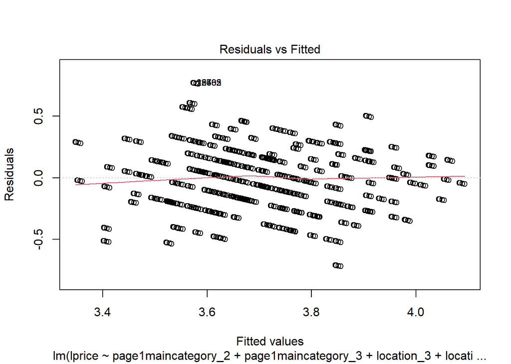

```r
#Linearity and Independence of Errors

plot(mod4, which = 1)
```

In the residuals versus fitted values plot, the points seem not totally randomly scattered

**Normality of residuals**

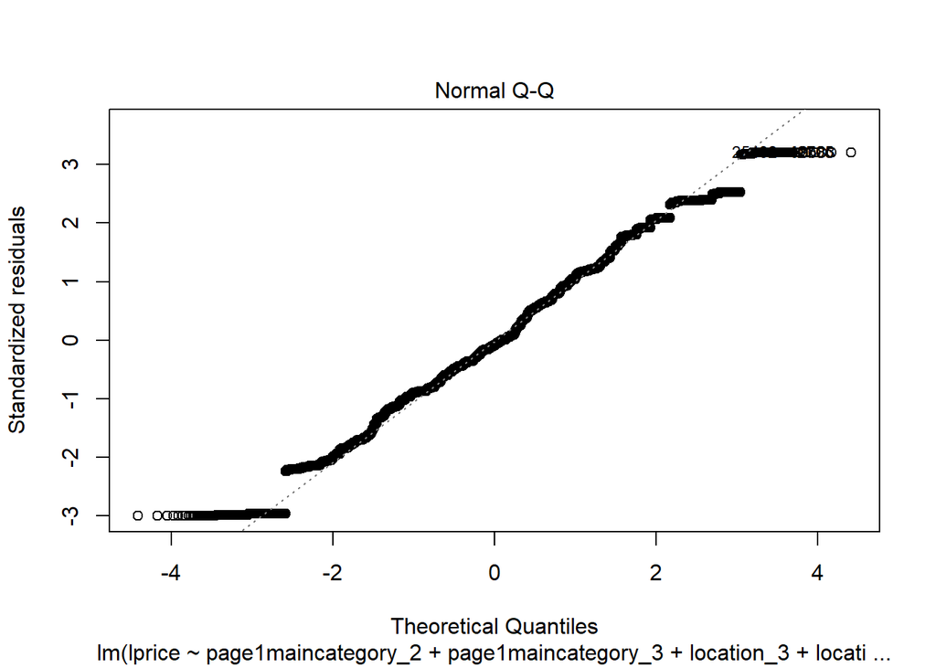

```r
plot(mod4, which = 2)
```

Most of the data points fall close to the line, but there does appear to be a flat curve and There is some data point that stand out.

#### f. Evaluate model on valid data set

```r
valid.df4<-dplyr::select(valid.df,lprice, page1maincategory, colour,location,modelphotography,page,month,continent,weekday)
valid.df4_dummy<-fastDummies::dummy_cols(valid.df4,select_columns = c("colour","page1maincategory","location","modelphotography","page","month","continent","weekday"),remove_first_dummy = T,remove_selected_columns = T)
head(valid.df4_dummy)
```

```
##     lprice colour_2 colour_3 colour_4 colour_5 colour_6 colour_7 colour_8
## 1 3.496508        0        0        0        0        0        0        0
## 2 3.951244        0        0        0        0        0        0        0
## 3 3.637586        0        0        0        0        1        0        0
## 4 4.043051        0        0        0        0        1        0        0
## 5 3.871201        0        0        0        0        1        0        0
## 6 4.043051        1        0        0        0        0        0        0
##   colour_9 colour_10 colour_11 colour_12 colour_13 colour_14
## 1        0         0         0         0         0         0
## 2        0         1         0         0         0         0
## 3        0         0         0         0         0         0
## 4        0         0         0         0         0         0
## 5        0         0         0         0         0         0
## 6        0         0         0         0         0         0
##   page1maincategory_2 page1maincategory_3 page1maincategory_4 location_2
```

[output cut: 41 more lines]

```r
pred_training4<- predict(mod4, data=train.df4_dummy, na.action=na.pass)
pred_valid4 <- predict(mod4, data=valid.df4_dummy, na.action=na.pass)
```

```r
## evaluate performance training
accuracy(pred_training4, train.df4_dummy$lprice)
```

```
##                     ME      RMSE       MAE        MPE     MAPE
## Test set -2.104887e-12 0.2401439 0.1919269 -0.4212303 5.177417
```

```r
## evaluate performance Validation
accuracy(pred_valid4, valid.df4_dummy$lprice)
```

```
##                    ME      RMSE      MAE       MPE     MAPE
## Test set 0.0001849509 0.3307404 0.267187 -0.608587 7.238002
```

This one has RMSE in valid dat smaller than the original model 4.

### 6/ Check for more better models!!!

```r
train.df4<-dplyr::select(train.df,lprice,page1maincategory, colour,location,modelphotography,page,month,continent,weekday)
head(train.df4,3)
```

```
##          lprice page1maincategory colour location modelphotography page month
## 24388  4.127134                 2     12        5                2    1     4
## 124413 3.496508                 3      6        2                1    1     7
## 69586  3.496508                 1     14        5                2    1     5
##        continent weekday
## 24388     Europe  Monday
## 124413   Website Tuesday
## 69586     Europe  Monday
```

#### a. Create dummy variables for train.df4

```r
##create dummy for categorical variables
train.df4_dummy<-fastDummies::dummy_cols(train.df4,select_columns=c("colour","page1maincategory","location","modelphotography","page","month","continent","weekday"),remove_selected_columns = T,remove_first_dummy = T)
```

```r
mod4<-lm(lprice~page1maincategory_2+page1maincategory_3+page1maincategory_4+colour_2+colour_3+colour_4+colour_5+colour_6+colour_7+colour_8+colour_9+colour_10+colour_11+colour_12+colour_13+colour_14+location_2+location_3+location_4+location_5+location_6+modelphotography_2+page_2+page_3+page_4+page_5+month_5+month_6+month_7+month_8+continent_Europe+continent_NorthAmerica+continent_Oceania+continent_Website+weekday_Monday+weekday_Saturday+weekday_Sunday+weekday_Thursday+weekday_Tuesday+weekday_Wednesday,data=train.df4_dummy)
summary(mod4)
```

```
##
## Call:
## lm(formula = lprice ~ page1maincategory_2 + page1maincategory_3 +
##     page1maincategory_4 + colour_2 + colour_3 + colour_4 + colour_5 +
##     colour_6 + colour_7 + colour_8 + colour_9 + colour_10 + colour_11 +
##     colour_12 + colour_13 + colour_14 + location_2 + location_3 +
##     location_4 + location_5 + location_6 + modelphotography_2 +
##     page_2 + page_3 + page_4 + page_5 + month_5 + month_6 + month_7 +
##     month_8 + continent_Europe + continent_NorthAmerica + continent_Oceania +
##     continent_Website + weekday_Monday + weekday_Saturday + weekday_Sunday +
##     weekday_Thursday + weekday_Tuesday + weekday_Wednesday, data = train.df4_dummy)
##
## Residuals:
##      Min       1Q   Median       3Q      Max
## -0.52248 -0.18119 -0.00468  0.18554  0.74340
##
## Coefficients:
##                          Estimate Std. Error t value Pr(>|t|)
## (Intercept)             3.4944657  0.0804437  43.440  < 2e-16 ***
## page1maincategory_2     0.0983951  0.0025689  38.303  < 2e-16 ***
## page1maincategory_3    -0.1262165  0.0026351 -47.899  < 2e-16 ***
## page1maincategory_4    -0.2455804  0.0024607 -99.800  < 2e-16 ***
## colour_2                0.2478488  0.0040023  61.927  < 2e-16 ***
## colour_3                0.2739811  0.0040280  68.019  < 2e-16 ***
## colour_4                0.2105301  0.0043813  48.051  < 2e-16 ***
## colour_5                0.1311427  0.0086659  15.133  < 2e-16 ***
## colour_6                0.1253519  0.0043574  28.768  < 2e-16 ***
## colour_7                0.0198154  0.0053124   3.730 0.000192 ***
## colour_8               -0.2903963  0.0068433 -42.435  < 2e-16 ***
## colour_9                0.1656835  0.0047089  35.185  < 2e-16 ***
## colour_10               0.2933632  0.0067769  43.289  < 2e-16 ***
## colour_11               0.3255057  0.0057982  56.139  < 2e-16 ***
## colour_12               0.2560137  0.0049701  51.511  < 2e-16 ***
## colour_13               0.0592492  0.0054449  10.882  < 2e-16 ***
## colour_14               0.1928273  0.0044646  43.190  < 2e-16 ***
## location_2             -0.1035839  0.0025057 -41.340  < 2e-16 ***
## location_3              0.0206889  0.0026507   7.805 6.01e-15 ***
## location_4             -0.0531942  0.0026212 -20.294  < 2e-16 ***
## location_5             -0.1082513  0.0027668 -39.125  < 2e-16 ***
## location_6             -0.0263010  0.0028692  -9.167  < 2e-16 ***
```

[output cut: 10 more lines]

```
## continent_NorthAmerica  0.1799679  0.0830758   2.166 0.030290 *
## continent_Oceania       0.0298894  0.1795564   0.166 0.867793
## continent_Website       0.1733004  0.0804346   2.155 0.031199 *
## weekday_Monday          0.0014068  0.0026852   0.524 0.600328
## weekday_Saturday        0.0006563  0.0029877   0.220 0.826125
## weekday_Sunday         -0.0028139  0.0028943  -0.972 0.330951
## weekday_Thursday       -0.0019091  0.0026894  -0.710 0.477781
## weekday_Tuesday        -0.0027905  0.0026057  -1.071 0.284207
## weekday_Wednesday       0.0012847  0.0026212   0.490 0.624055
## ---
## Signif. codes:  0 '***' 0.001 '**' 0.01 '*' 0.05 '.' 0.1 ' ' 1
##
## Residual standard error: 0.227 on 99243 degrees of freedom
## Multiple R-squared:  0.3831, Adjusted R-squared:  0.3829
## F-statistic:  1541 on 40 and 99243 DF,  p-value: < 2.2e-16
```

```r
mod4<-lm(lprice~page1maincategory_2+page1maincategory_3+colour_2+colour_3+colour_4+colour_5+colour_6+colour_7+colour_8+colour_9+colour_10+colour_11+colour_12+colour_13+colour_14+location_2+location_3+location_4+location_5+location_6+modelphotography_2+page_2+page_3+page_4+page_5+month_5+month_6,data=train.df4_dummy)
summary(mod4)
```

```
##
## Call:
## lm(formula = lprice ~ page1maincategory_2 + page1maincategory_3 +
##     colour_2 + colour_3 + colour_4 + colour_5 + colour_6 + colour_7 +
##     colour_8 + colour_9 + colour_10 + colour_11 + colour_12 +
##     colour_13 + colour_14 + location_2 + location_3 + location_4 +
##     location_5 + location_6 + modelphotography_2 + page_2 + page_3 +
##     page_4 + page_5 + month_5 + month_6, data = train.df4_dummy)
##
## Residuals:
##      Min       1Q   Median       3Q      Max
## -0.66767 -0.15402 -0.01661  0.17397  0.73572
##
## Coefficients:
##                       Estimate Std. Error t value Pr(>|t|)
## (Intercept)          3.6103612  0.0042175 856.044  < 2e-16 ***
## page1maincategory_2  0.2251925  0.0023420  96.156  < 2e-16 ***
## page1maincategory_3  0.0224670  0.0022798   9.855  < 2e-16 ***
## colour_2             0.1482310  0.0040627  36.486  < 2e-16 ***
## colour_3             0.2693954  0.0042216  63.814  < 2e-16 ***
## colour_4             0.0851964  0.0044000  19.363  < 2e-16 ***
## colour_5             0.0579668  0.0090541   6.402 1.54e-10 ***
## colour_6             0.0365730  0.0044737   8.175 2.99e-16 ***
## colour_7            -0.1370791  0.0053233 -25.751  < 2e-16 ***
## colour_8            -0.2583059  0.0071665 -36.043  < 2e-16 ***
## colour_9             0.0180975  0.0046895   3.859 0.000114 ***
## colour_10            0.1933846  0.0070299  27.509  < 2e-16 ***
## colour_11            0.2015479  0.0059412  33.924  < 2e-16 ***
## colour_12            0.1636744  0.0051213  31.960  < 2e-16 ***
## colour_13           -0.0373138  0.0056202  -6.639 3.17e-11 ***
## colour_14            0.0917832  0.0045611  20.123  < 2e-16 ***
## location_2          -0.0765945  0.0026131 -29.311  < 2e-16 ***
## location_3           0.0278298  0.0027794  10.013  < 2e-16 ***
## location_4          -0.0203209  0.0027274  -7.451 9.37e-14 ***
## location_5          -0.0722422  0.0028774 -25.107  < 2e-16 ***
## location_6          -0.0008321  0.0029975  -0.278 0.781312
## modelphotography_2  -0.1054471  0.0019577 -53.862  < 2e-16 ***
## page_2               0.0812089  0.0020573  39.473  < 2e-16 ***
## page_3              -0.0580774  0.0027800 -20.891  < 2e-16 ***
## page_4               0.0797598  0.0040483  19.702  < 2e-16 ***
## page_5               0.1746109  0.0063275  27.596  < 2e-16 ***
## month_5             -0.0020629  0.0019111  -1.079 0.280407
## month_6             -0.0032396  0.0019779  -1.638 0.101445
## ---
## Signif. codes:  0 '***' 0.001 '**' 0.01 '*' 0.05 '.' 0.1 ' ' 1
##
## Residual standard error: 0.2382 on 99256 degrees of freedom
## Multiple R-squared:  0.321,  Adjusted R-squared:  0.3208
## F-statistic:  1738 on 27 and 99256 DF,  p-value: < 2.2e-16
```

#### e. Check L.I.N.E assumptions

**Checking for Multicollinearity (VIF test)**

```r
vif4<- tidy(vif(mod4))
kable(vif4,
caption="Variance product's attributes for the 'lprice' regression model",
col.names=c("regressor","VIF"))%>%
kable_styling(full_width = T)
```

Variance product’s attributes for the ‘lprice’ regression model

| regressor | VIF |
| --- | --- |
| page1maincategory_2 | 1.714870 |
| page1maincategory_3 | 1.623602 |
| colour_2 | 4.265142 |
| colour_3 | 4.541132 |
| colour_4 | 3.048068 |
| colour_5 | 1.423321 |
| colour_6 | 3.327087 |
| colour_7 | 1.984870 |
| colour_8 | 1.449630 |
| colour_9 | 2.878168 |
| colour_10 | 1.773909 |
| colour_11 | 1.922106 |
| colour_12 | 2.351170 |
| colour_13 | 1.983257 |
| colour_14 | 3.152653 |
| location_2 | 1.920293 |
| location_3 | 1.549444 |
| location_4 | 1.790326 |
| location_5 | 2.027038 |
| location_6 | 1.719953 |
| modelphotography_2 | 1.288432 |
| page_2 | 1.381097 |
| page_3 | 1.393761 |
| page_4 | 1.439006 |
| page_5 | 1.180525 |
| month_5 | 1.075914 |
| month_6 | 1.074511 |

**Heteroscedasticity (breusch pagan test - bptest)**

```r
bptest(mod4)
```

```
##
##  studentized Breusch-Pagan test
##
## data:  mod4
## BP = 13702, df = 27, p-value < 2.2e-16
```

**Linearity and Independence of Errors**

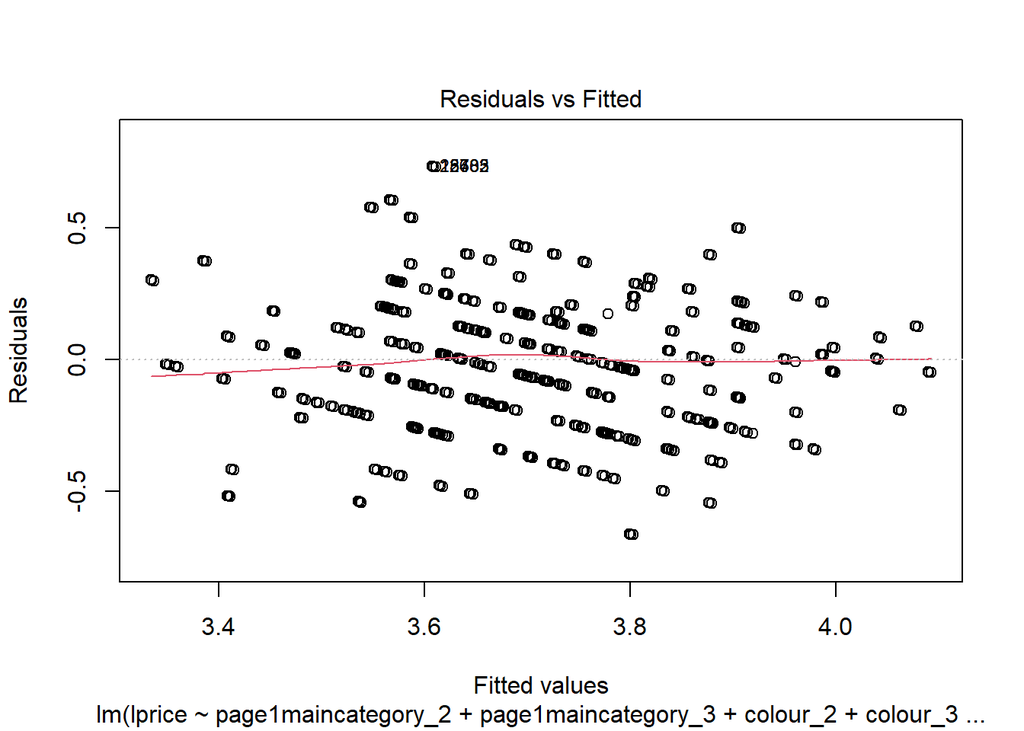

```r
#Linearity and Independence of Errors

plot(mod4, which = 1)
```

In the residuals versus fitted values plot, the points seem not totally randomly scattered

**Normality of residuals**

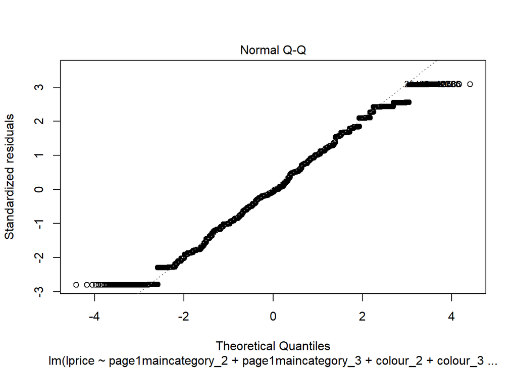

```r
plot(mod4, which = 2)
```

Most of the data points fall close to the line, but there does appear to be a flat curve and There is some data point that stand out.

#### f. Evaluate model on valid data set

```r
valid.df4<-dplyr::select(valid.df,lprice, page1maincategory, colour,location,modelphotography,page,month,continent,weekday)
valid.df4_dummy<-fastDummies::dummy_cols(valid.df4,select_columns = c("colour","page1maincategory","location","modelphotography","page","month","continent","weekday"),remove_first_dummy = T,remove_selected_columns = T)
head(valid.df4_dummy)
```

```
##     lprice colour_2 colour_3 colour_4 colour_5 colour_6 colour_7 colour_8
## 1 3.496508        0        0        0        0        0        0        0
## 2 3.951244        0        0        0        0        0        0        0
## 3 3.637586        0        0        0        0        1        0        0
## 4 4.043051        0        0        0        0        1        0        0
## 5 3.871201        0        0        0        0        1        0        0
## 6 4.043051        1        0        0        0        0        0        0
##   colour_9 colour_10 colour_11 colour_12 colour_13 colour_14
## 1        0         0         0         0         0         0
## 2        0         1         0         0         0         0
## 3        0         0         0         0         0         0
## 4        0         0         0         0         0         0
## 5        0         0         0         0         0         0
## 6        0         0         0         0         0         0
##   page1maincategory_2 page1maincategory_3 page1maincategory_4 location_2
```

[output cut: 41 more lines]

```r
pred_training4<- predict(mod4, data=train.df4_dummy, na.action=na.pass)
pred_valid4 <- predict(mod4, data=valid.df4_dummy, na.action=na.pass)
```

```r
## evaluate performance training
accuracy(pred_training4, train.df4_dummy$lprice)
```

```
##                     ME      RMSE      MAE       MPE     MAPE
## Test set -2.097047e-12 0.2381533 0.188816 -0.414621 5.096824
```

```r
## evaluate performance Validation
accuracy(pred_valid4, valid.df4_dummy$lprice)
```

```
##                    ME      RMSE       MAE        MPE     MAPE
## Test set 8.923626e-05 0.3319566 0.2680843 -0.6106481 7.262091
```

## Model 2 - Logistic Regresion: Which attributes predict whether a product is going to be sold at premium price?

```r
knitr::opts_chunk$set(echo = TRUE)

library(tidyverse)
library(readr)
library(gains)
library(lessR)
library(caret)
library(fastDummies)
```

### Removing Sales category from datset

```r
# Loading the dataset
df <- readr::read_csv("eshopcontinent.csv")
# Removing Sales category from datset
df<-df[!(df$page1maincategory==4),]


head(df)
```

```
## # A tibble: 6 x 17
##    year month   day order country continent sessionID page1maincategory
##   <dbl> <dbl> <dbl> <dbl>   <dbl> <chr>         <dbl>             <dbl>
## 1  2008     4     1     1      29 Europe            1                 1
## 2  2008     4     1     2      29 Europe            1                 1
## 3  2008     4     1     3      29 Europe            1                 2
## 4  2008     4     1     4      29 Europe            1                 2
## 5  2008     4     1     5      29 Europe            1                 2
## 6  2008     4     1     6      29 Europe            1                 3
## # ... with 9 more variables: page2clothingmodel <chr>, colour <dbl>,
## #   location <dbl>, modelphotography <dbl>, price <dbl>, price2 <dbl>,
## #   page <dbl>, weekday <chr>, formal <dbl>
```

### Converting categorical variables into factors

```r
# Converting categorical variables into factors
df$month = as.factor(df$month)
df$weekday = as.factor(df$weekday)
df$continent = as.factor(df$continent)
df$country = as.factor(df$country)
df$page1maincategory = as.factor(df$page1maincategory)
df$location = as.factor(df$location)
df$modelphotography = as.factor(df$modelphotography)
df$page = as.factor(df$page)
```

### Creating a dummy for categorical variables

```r
df<-fastDummies::dummy_cols(df,select_columns=c("continent","month","page1maincategory","location","modelphotography","page","weekday","colour","formal"),remove_selected_columns = T, remove_first_dummy = T)

head(df)
```

```
## # A tibble: 6 x 47
##    year   day order country sessionID page2clothingmodel price price2
##   <dbl> <dbl> <dbl> <fct>       <dbl> <chr>              <dbl>  <dbl>
## 1  2008     1     1 29              1 A13                   28      0
## 2  2008     1     2 29              1 A16                   33      0
## 3  2008     1     3 29              1 B4                    52      1
## 4  2008     1     4 29              1 B17                   38      0
## 5  2008     1     5 29              1 B8                    52      1
## 6  2008     1     6 29              1 C56                   57      1
## # ... with 39 more variables: continent_Europe <int>,
## #   continent_NorthAmerica <int>, continent_Oceania <int>,
## #   continent_Website <int>, month_5 <int>, month_6 <int>, month_7 <int>,
## #   month_8 <int>, page1maincategory_2 <int>, page1maincategory_3 <int>,
## #   location_2 <int>, location_3 <int>, location_4 <int>, location_5 <int>,
## #   location_6 <int>, modelphotography_2 <int>, page_2 <int>, page_3 <int>,
## #   page_4 <int>, weekday_Monday <int>, weekday_Saturday <int>, ...
```

```r
colnames(df)
```

```
##  [1] "year"                   "day"                    "order"
##  [4] "country"                "sessionID"              "page2clothingmodel"
##  [7] "price"                  "price2"                 "continent_Europe"
## [10] "continent_NorthAmerica" "continent_Oceania"      "continent_Website"
## [13] "month_5"                "month_6"                "month_7"
## [16] "month_8"                "page1maincategory_2"    "page1maincategory_3"
## [19] "location_2"             "location_3"             "location_4"
## [22] "location_5"             "location_6"             "modelphotography_2"
## [25] "page_2"                 "page_3"                 "page_4"
## [28] "weekday_Monday"         "weekday_Saturday"       "weekday_Sunday"
## [31] "weekday_Thursday"       "weekday_Tuesday"        "weekday_Wednesday"
## [34] "colour_2"               "colour_3"               "colour_4"
## [37] "colour_5"               "colour_6"               "colour_7"
## [40] "colour_8"               "colour_9"               "colour_10"
## [43] "colour_11"              "colour_12"              "colour_13"
## [46] "colour_14"              "formal_1"
```

### Creating a dataframe named t1 and saving all required variables for logistic regression

```r
names(df)
```

```
##  [1] "year"                   "day"                    "order"
##  [4] "country"                "sessionID"              "page2clothingmodel"
##  [7] "price"                  "price2"                 "continent_Europe"
## [10] "continent_NorthAmerica" "continent_Oceania"      "continent_Website"
## [13] "month_5"                "month_6"                "month_7"
## [16] "month_8"                "page1maincategory_2"    "page1maincategory_3"
## [19] "location_2"             "location_3"             "location_4"
## [22] "location_5"             "location_6"             "modelphotography_2"
## [25] "page_2"                 "page_3"                 "page_4"
## [28] "weekday_Monday"         "weekday_Saturday"       "weekday_Sunday"
## [31] "weekday_Thursday"       "weekday_Tuesday"        "weekday_Wednesday"
## [34] "colour_2"               "colour_3"               "colour_4"
## [37] "colour_5"               "colour_6"               "colour_7"
## [40] "colour_8"               "colour_9"               "colour_10"
## [43] "colour_11"              "colour_12"              "colour_13"
## [46] "colour_14"              "formal_1"
```

```r
t1.df <- select(df,page1maincategory_2,page1maincategory_3,
                location_3,location_5,location_6,modelphotography_2,page_2,page_3,page_4,
                month_5,month_6,month_7,month_8,
                price2,
                colour_2,colour_3,colour_4,colour_5,colour_6,colour_7,colour_8,colour_9,colour_10,colour_11,colour_12,colour_13,colour_14

                )
# To get same reults every time
set.seed(2)

# Setting training size to 60%
t1.train.index <- sample(c(1:dim(t1.df)[1]), dim(t1.df)[1]*0.6)
t1.train.df <- t1.df[t1.train.index, ]
t1.valid.df <- t1.df[-t1.train.index, ]
```

### Using generalized linear model function to do logistic regression

```r
# Using generalized linear model function to do logistic regression
t1.logit.reg <- glm(price2 ~ ., data = t1.train.df, family = binomial (link = "logit"))
options(scipen=999)

# Summary of regression
summary(t1.logit.reg)
```

```
##
## Call:
## glm(formula = price2 ~ ., family = binomial(link = "logit"),
##     data = t1.train.df)
##
## Deviance Residuals:
##      Min        1Q    Median        3Q       Max
## -2.34349  -1.02199   0.00014   0.95983   2.18256
##
## Coefficients:
##                       Estimate Std. Error z value             Pr(>|z|)
## (Intercept)          -2.046705   0.047151 -43.408 < 0.0000000000000002 ***
## page1maincategory_2   0.972604   0.027029  35.983 < 0.0000000000000002 ***
## page1maincategory_3   1.051446   0.029689  35.415 < 0.0000000000000002 ***
## location_3            0.913195   0.026170  34.895 < 0.0000000000000002 ***
## location_5           -0.197250   0.026946  -7.320 0.000000000000247345 ***
## location_6            0.297438   0.029329  10.141 < 0.0000000000000002 ***
## modelphotography_2   -0.838891   0.023452 -35.770 < 0.0000000000000002 ***
## page_2                0.541532   0.022722  23.833 < 0.0000000000000002 ***
## page_3               -0.624487   0.033216 -18.801 < 0.0000000000000002 ***
## page_4               18.547322 102.754847   0.181                0.857
## month_5              -0.034263   0.024163  -1.418                0.156
## month_6              -0.024895   0.024823  -1.003                0.316
## month_7              -0.016713   0.024508  -0.682                0.495
## month_8              -0.004016   0.033710  -0.119                0.905
## colour_2              1.483197   0.046340  32.007 < 0.0000000000000002 ***
## colour_3              1.703777   0.047119  36.159 < 0.0000000000000002 ***
## colour_4              1.545634   0.053474  28.905 < 0.0000000000000002 ***
## colour_5            -17.059233 102.754880  -0.166                0.868
## colour_6              0.420612   0.051654   8.143 0.000000000000000386 ***
## colour_7             -0.698039   0.073794  -9.459 < 0.0000000000000002 ***
## colour_8            -15.844652  95.090743  -0.167                0.868
## colour_9              1.092171   0.054893  19.896 < 0.0000000000000002 ***
## colour_10            18.656728  85.121289   0.219                0.827
## colour_11            18.300825  72.840329   0.251                0.802
## colour_12             3.133366   0.062502  50.132 < 0.0000000000000002 ***
## colour_13             0.360315   0.058734   6.135 0.000000000852991962 ***
## colour_14             1.686451   0.053763  31.369 < 0.0000000000000002 ***
## ---
## Signif. codes:  0 '***' 0.001 '**' 0.01 '*' 0.05 '.' 0.1 ' ' 1
##
## (Dispersion parameter for binomial family taken to be 1)
##
##     Null deviance: 105405  on 76035  degrees of freedom
## Residual deviance:  80196  on 76009  degrees of freedom
## AIC: 80250
##
## Number of Fisher Scoring iterations: 16
```

```r
round(data.frame(summary(t1.logit.reg)$coefficients, odds = exp(coef(t1.logit.reg))),5)
```

```
##                      Estimate Std..Error   z.value Pr...z..            odds
## (Intercept)          -2.04671    0.04715 -43.40786  0.00000         0.12916
## page1maincategory_2   0.97260    0.02703  35.98325  0.00000         2.64482
## page1maincategory_3   1.05145    0.02969  35.41483  0.00000         2.86179
## location_3            0.91320    0.02617  34.89479  0.00000         2.49227
## location_5           -0.19725    0.02695  -7.32034  0.00000         0.82098
## location_6            0.29744    0.02933  10.14149  0.00000         1.34641
## modelphotography_2   -0.83889    0.02345 -35.77038  0.00000         0.43219
## page_2                0.54153    0.02272  23.83334  0.00000         1.71864
## page_3               -0.62449    0.03322 -18.80076  0.00000         0.53554
## page_4               18.54732  102.75485   0.18050  0.85676 113501000.35366
## month_5              -0.03426    0.02416  -1.41796  0.15620         0.96632
## month_6              -0.02489    0.02482  -1.00288  0.31592         0.97541
## month_7              -0.01671    0.02451  -0.68196  0.49526         0.98343
## month_8              -0.00402    0.03371  -0.11915  0.90516         0.99599
## colour_2              1.48320    0.04634  32.00667  0.00000         4.40701
## colour_3              1.70378    0.04712  36.15924  0.00000         5.49466
## colour_4              1.54563    0.05347  28.90463  0.00000         4.69094
## colour_5            -17.05923  102.75488  -0.16602  0.86814         0.00000
## colour_6              0.42061    0.05165   8.14280  0.00000         1.52289
## colour_7             -0.69804    0.07379  -9.45927  0.00000         0.49756
## colour_8            -15.84465   95.09074  -0.16663  0.86766         0.00000
## colour_9              1.09217    0.05489  19.89633  0.00000         2.98074
## colour_10            18.65673   85.12129   0.21918  0.82651 126623441.37817
## colour_11            18.30082   72.84033   0.25125  0.80162  88704799.36652
## colour_12             3.13337    0.06250  50.13214  0.00000        22.95111
## colour_13             0.36032    0.05873   6.13474  0.00000         1.43378
## colour_14             1.68645    0.05376  31.36851  0.00000         5.40028
```

### Predicting first 5 premium against Validation Data

```r
t1.logit.reg.pred <- predict(t1.logit.reg, t1.valid.df, type = "response")
data.frame(actual = t1.valid.df$price2[1:5], predicted = t1.logit.reg.pred[1:5])
```

```
##   actual  predicted
## 1      0 0.09587212
## 2      0 0.23237621
## 3      1 0.63316924
## 4      1 0.58960926
## 5      1 0.93091283
```

### Creating a confusion matrix at cutoff 0.45

```r
t1.logit.reg.pred2<-ifelse(t1.logit.reg.pred>0.45, 1 ,0)
confusionMatrix(as.factor(t1.logit.reg.pred2), as.factor(t1.valid.df$price2),positive='1')
```

```
## Confusion Matrix and Statistics
##
##           Reference
## Prediction     0     1
##          0 19123  6187
##          1  6136 19245
##
##                Accuracy : 0.7569
##                  95% CI : (0.7531, 0.7606)
##     No Information Rate : 0.5017
##     P-Value [Acc > NIR] : <0.0000000000000002
##
##                   Kappa : 0.5138
##
##  Mcnemar's Test P-Value : 0.6524
##
##             Sensitivity : 0.7567
##             Specificity : 0.7571
##          Pos Pred Value : 0.7582
##          Neg Pred Value : 0.7556
##              Prevalence : 0.5017
##          Detection Rate : 0.3797
##    Detection Prevalence : 0.5007
##       Balanced Accuracy : 0.7569
##
##        'Positive' Class : 1
##
```

### Creating a Gains chart and Decile-wise chart

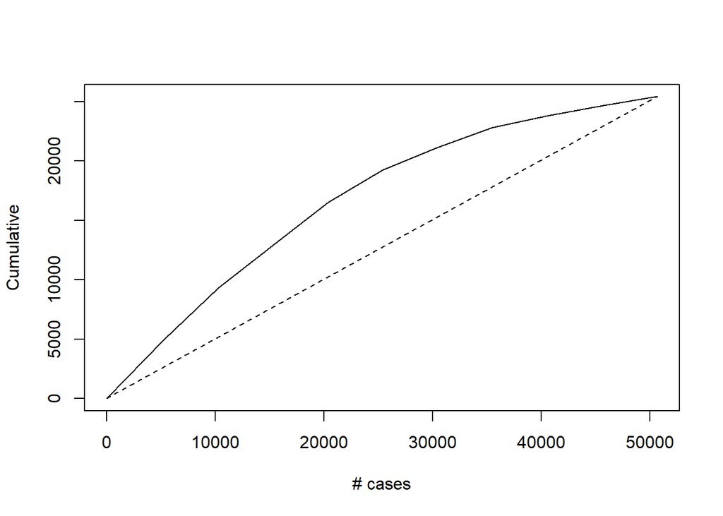

```r
gain <- gains(t1.valid.df$price2, t1.logit.reg.pred, groups=10)

plot(c(0,gain$cume.pct.of.total*sum(t1.valid.df$price2))~c(0,gain$cume.obs),
xlab="# cases", ylab="Cumulative", main="", type="l")
lines(c(0,sum(t1.valid.df$price2))~c(0, dim(t1.valid.df)[1]), lty=2)
```

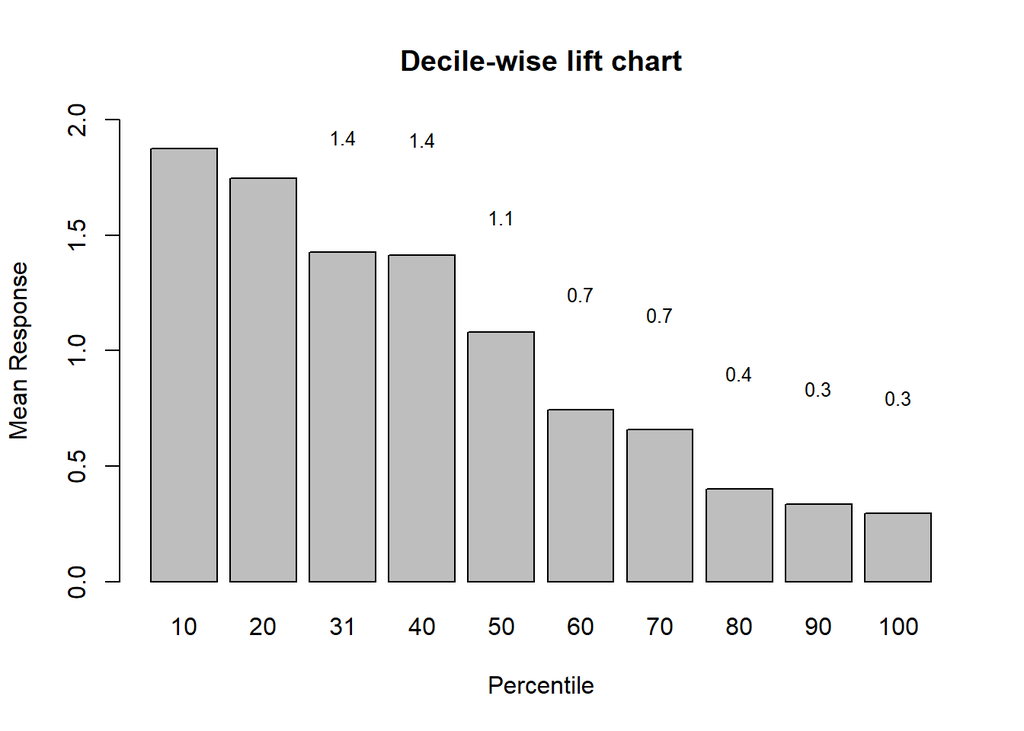

```r
# compute deciles and plot decile-wise chart
heights <- gain$mean.resp/mean( t1.valid.df$price2)
midpoints <- barplot(heights, names.arg = gain$depth, ylim = c(0, 2),
                     xlab = "Percentile", ylab = "Mean Response", main = "Decile-wise lift chart")
# add labels to columns
text(midpoints, heights+0.5, labels=round(heights, 1), cex = 0.8)
```

### Conclusion: Our model predicts almost twice (1.9 times) as many premium purchasers in the first 10% of customers than choosing 10% at random.